# Optimal Control Results

# Cholera

Here we keep the results of various numerical experiments of optimal control outcomes in the Cholera model. Specifically, we focus on the difference between the optimal strategy, when control is customized to each patch versus the “one size fits all strategy” where both patches are forced to be given the same control.

## Experiment 0 (no movement between patches)

### Parameters

The following experiments use these parameters and initial conditions.

Parameters:

| mu1 | mu2 | beta_I1 | beta_I2 | beta_W1 | beta_W2 | v1 | v2 | u1 | u2 | m1 | m2 | n1 | n2 | gamma1 | gamma2 |
| --- | --- | --- | --- | --- | --- | --- | --- | --- | --- | --- | --- | --- | --- | --- | --- |
| 0 | 0 | 2.64e-06 | 2.64e-06 | 1.01e-05 | 1.01e-05 | 0 | 0 | 0 | 0 | 0 | 0 | 0 | 0 | 0.25 | 0.25 |

| delta1 | delta2 | xi1 | xi2 | nu1 | nu2 | rho1 | rho2 |
| --- | --- | --- | --- | --- | --- | --- | --- |
| 5e-04 | 5e-04 | 0.00756 | 0.00756 | 0.00756 | 0.00756 | 0.025 | 0.025 |

Initial conditions:

| S1 | S2 | I1 | I2 | R1 | R2 | W1 | W2 |
| --- | --- | --- | --- | --- | --- | --- | --- |
| 92791 | 94406 | 1609 | 1440 | 5589 | 4145 | 118 | 120 |

Optimal control parameters:

| b1 | b2 | C1 | C2 | epsilon1 | epsilon2 | D1 | D2 | eta1 | eta2 | tol | control_type |
| --- | --- | --- | --- | --- | --- | --- | --- | --- | --- | --- | --- |
| 1 | 1 | 0.125 | 0.125 | 10000 | 10000 | 0.0125 | 0.0125 | 1000 | 1000 | 0.01 | unique |

| v1_min | v1_max | v2_min | v2_max | u1_min | u1_max | u2_min | u2_max |
| --- | --- | --- | --- | --- | --- | --- | --- |
| 0 | 0.015 | 0 | 0.015 | 0 | 0.4 | 0 | 0.4 |

### No control

Time 0 corresponds to 100 days since the start of the outbreak.

### Vaccination Only

We consider the case with only vaccination (no sanitation).

Controls start at day 100.

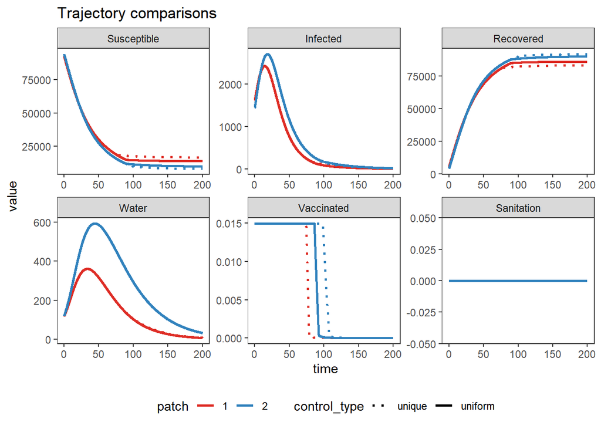

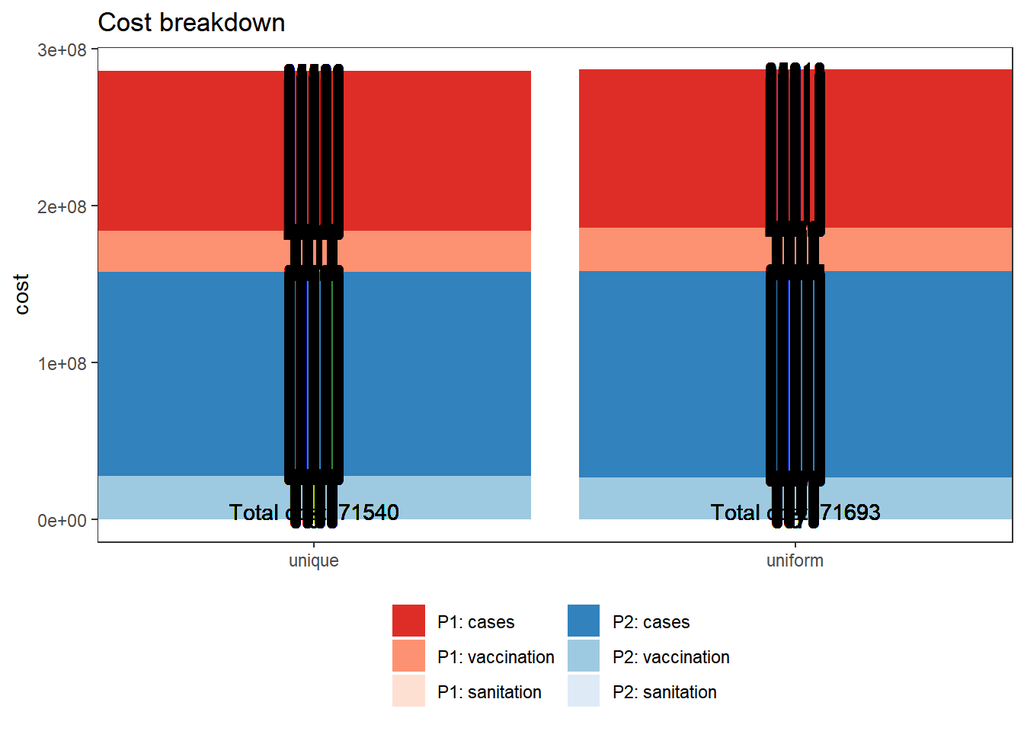

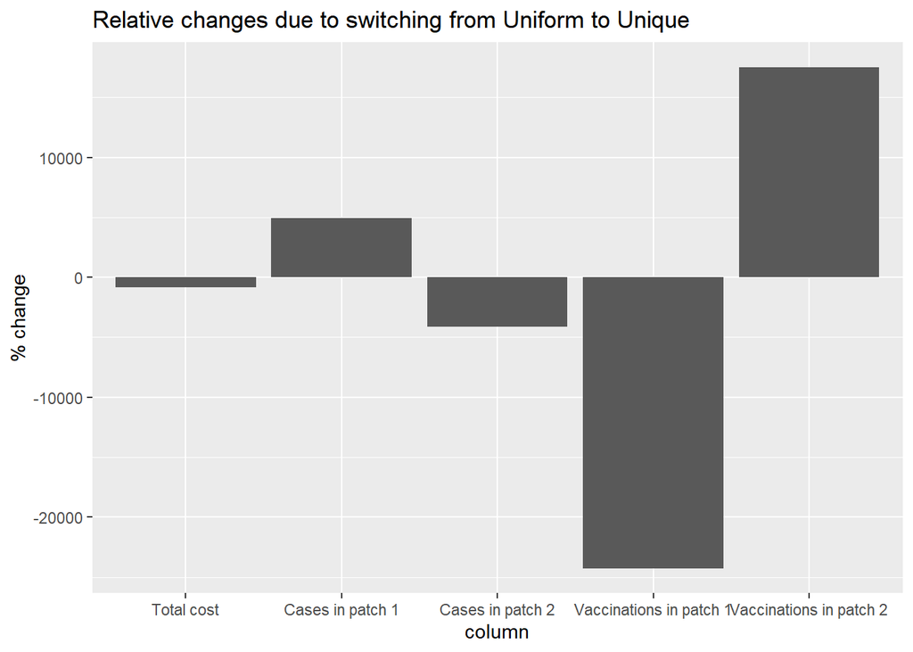

### Sanitation Only

We also consider the case with only sanitation (no vaccination).

Controls start at day 100`.

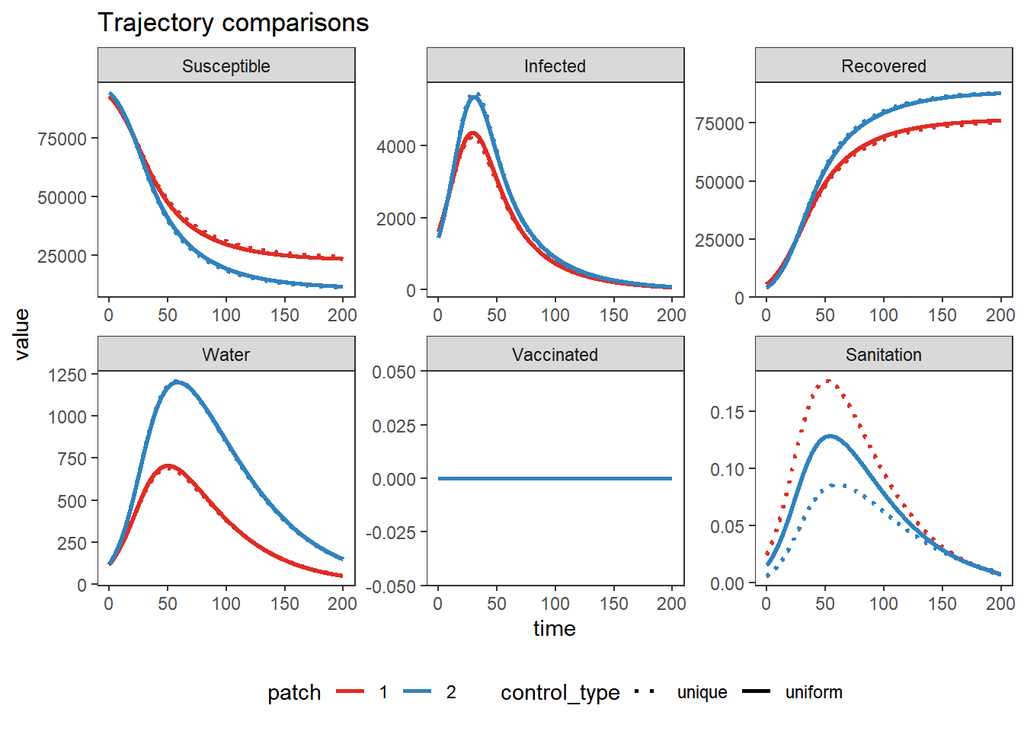

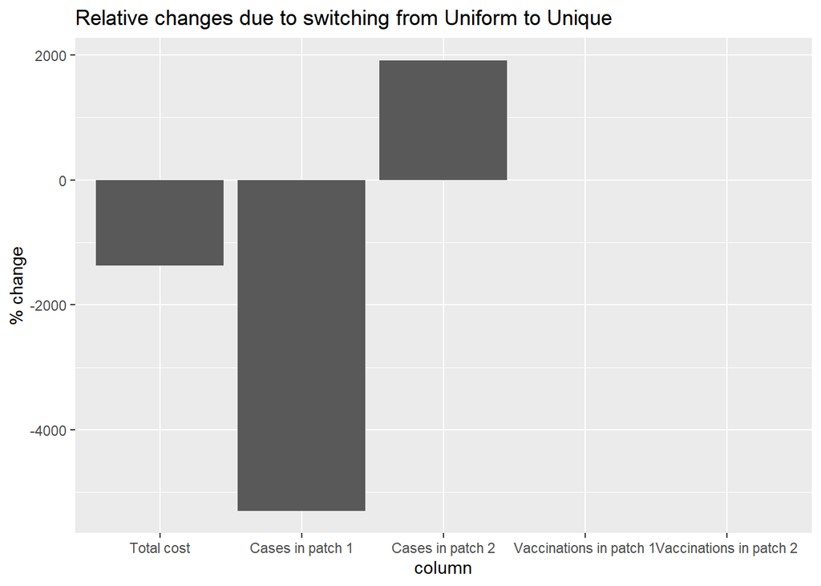

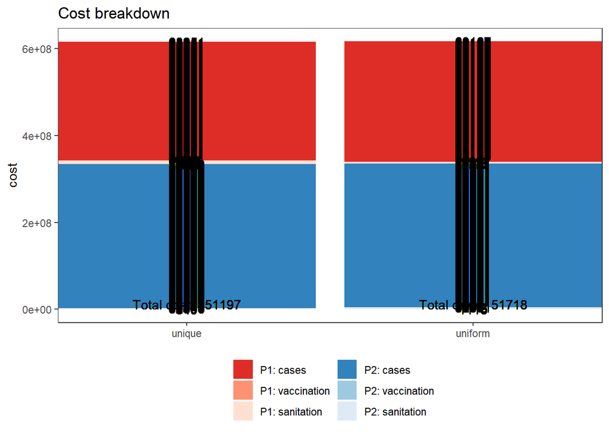

### Both Vaccination and Sanitation

Lastly, we show how results change if we optimize both controls.

Controls start at day 100.

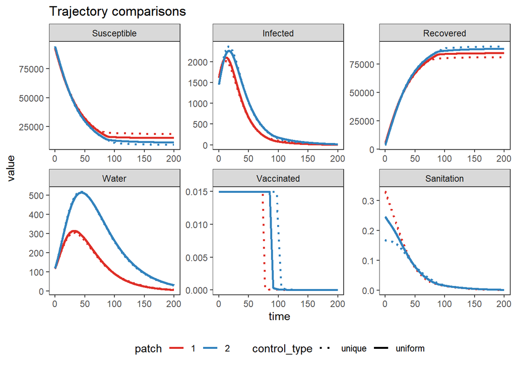

[figure not shown]

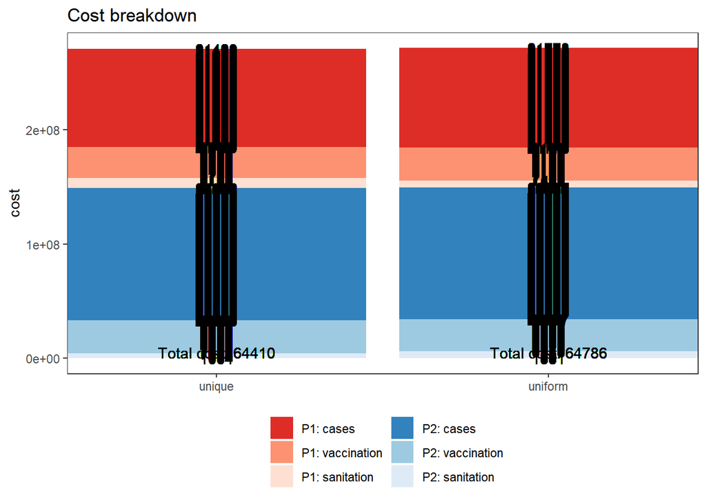

## Experiment 1 (symmetric, m1=m2=0.05)

### Parameters

The following experiments use these parameters and initial conditions.

Parameters:

| mu1 | mu2 | beta_I1 | beta_I2 | beta_W1 | beta_W2 | v1 | v2 | u1 | u2 | m1 | m2 | n1 | n2 | gamma1 | gamma2 |
| --- | --- | --- | --- | --- | --- | --- | --- | --- | --- | --- | --- | --- | --- | --- | --- |
| 0 | 0 | 2.6e-06 | 2.6e-06 | 1.01e-05 | 1.01e-05 | 0 | 0 | 0 | 0 | 0.05 | 0.05 | 0 | 0 | 0.25 | 0.25 |

| delta1 | delta2 | xi1 | xi2 | nu1 | nu2 | rho1 | rho2 |
| --- | --- | --- | --- | --- | --- | --- | --- |
| 5e-04 | 5e-04 | 0.00756 | 0.00756 | 0.00756 | 0.00756 | 0.025 | 0.025 |

Initial conditions: **need to re-calculate initial conditions with movement**

| S1 | S2 | I1 | I2 | R1 | R2 | W1 | W2 |
| --- | --- | --- | --- | --- | --- | --- | --- |
| 92791 | 94406 | 1609 | 1440 | 5589 | 4145 | 118 | 120 |

Optimal control parameters:

| b1 | b2 | C1 | C2 | epsilon1 | epsilon2 | D1 | D2 | eta1 | eta2 | tol | control_type |
| --- | --- | --- | --- | --- | --- | --- | --- | --- | --- | --- | --- |
| 1 | 1 | 0.125 | 0.125 | 10000 | 10000 | 0.0125 | 0.0125 | 1000 | 1000 | 0.01 | unique |

| v1_min | v1_max | v2_min | v2_max | u1_min | u1_max | u2_min | u2_max |
| --- | --- | --- | --- | --- | --- | --- | --- |
| 0 | 0.015 | 0 | 0.015 | 0 | 0.4 | 0 | 0.4 |

With these parameters, the system has an R0 of about 1.9898893.

### No control

Time 0 corresponds to 100 days since the start of the outbreak. **This is currently incorrect. It’s not taking into account movement**

### Vaccination Only

We consider the case with only vaccination (no sanitation).

Controls start at day 100.

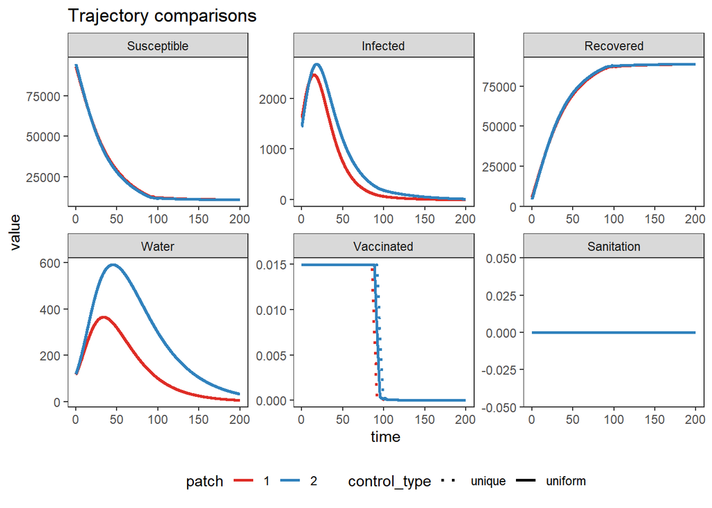

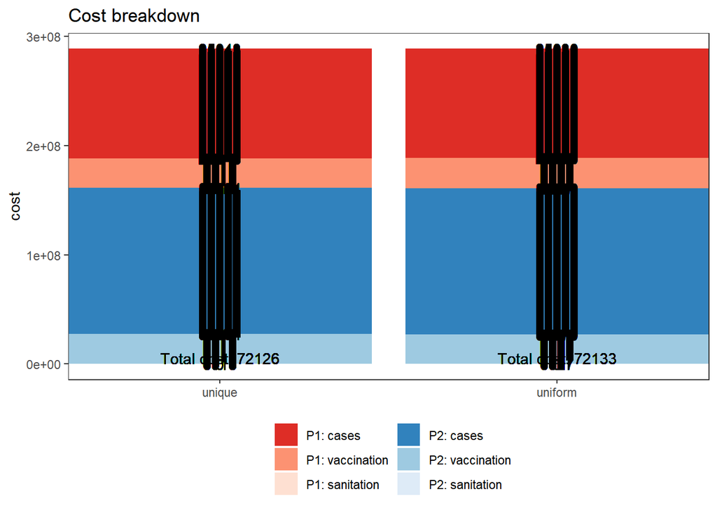

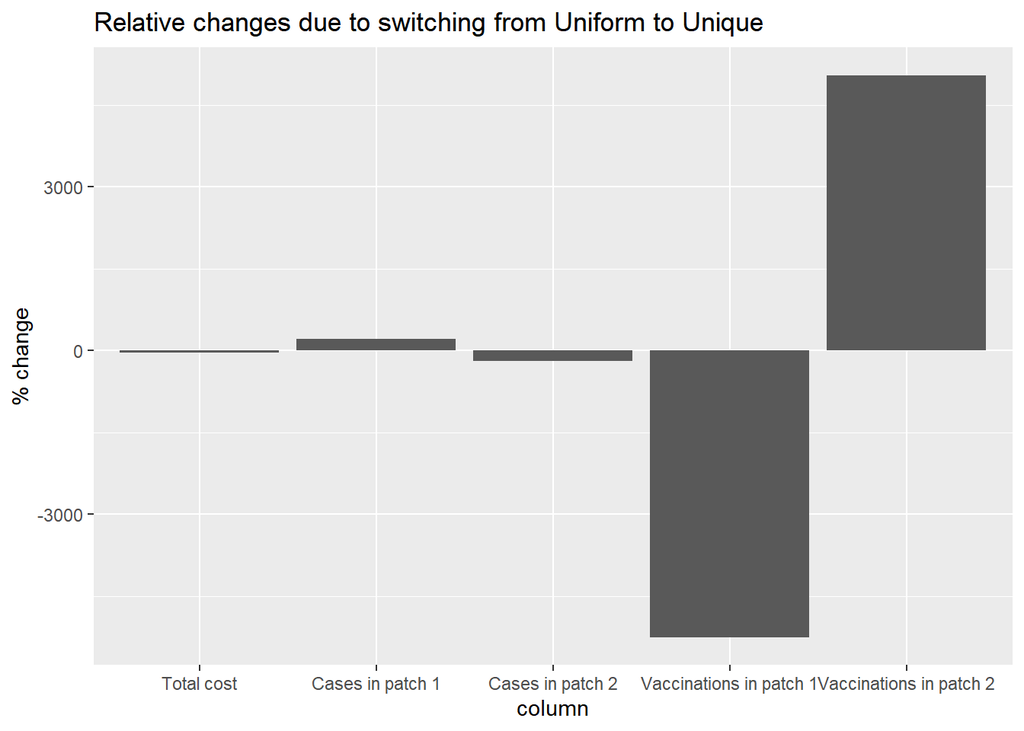

### Sanitation Only

We also consider the case with only sanitation (no vaccination).

Controls start at day 100`.

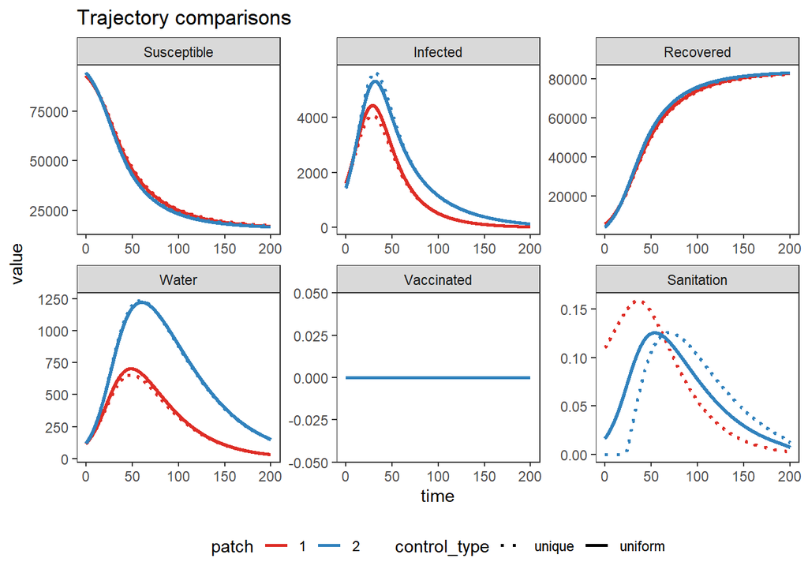

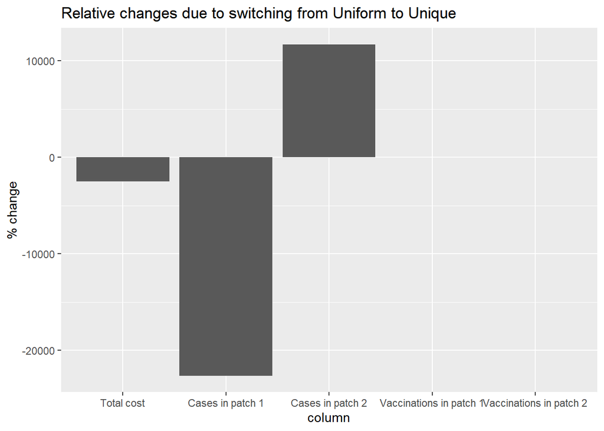

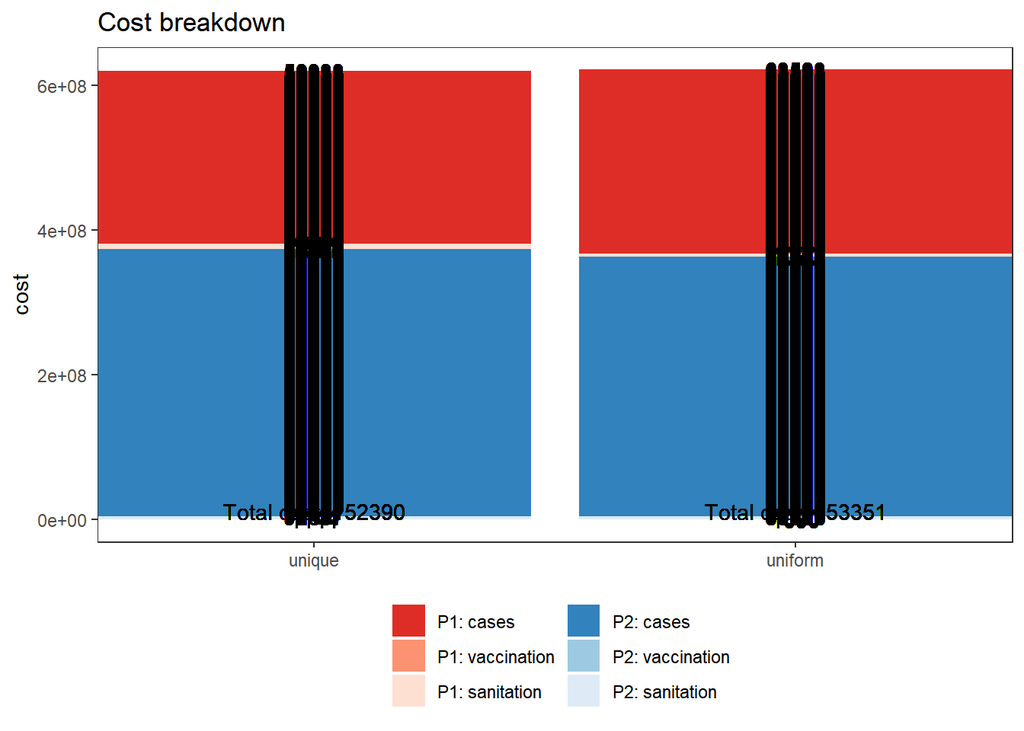

### Both Vaccination and Sanitation

Lastly, we show how results change if we optimize both controls.

Controls start at day 100.

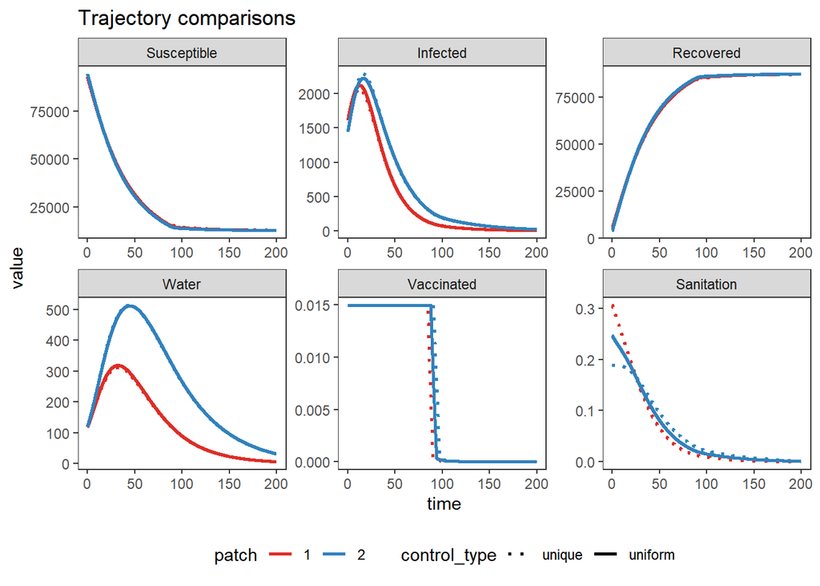

[figure not shown]

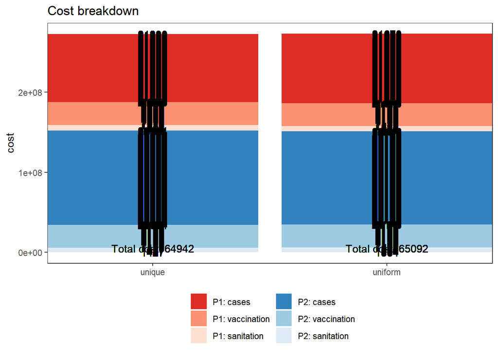

## Experiment 2 (symmetric movement, m1=m2=0.1)

### Parameters

The following experiments use these parameters and initial conditions.

Parameters:

| mu1 | mu2 | beta_I1 | beta_I2 | beta_W1 | beta_W2 | v1 | v2 | u1 | u2 | m1 | m2 | n1 | n2 | gamma1 | gamma2 |
| --- | --- | --- | --- | --- | --- | --- | --- | --- | --- | --- | --- | --- | --- | --- | --- |
| 0 | 0 | 2.6e-06 | 2.6e-06 | 1.01e-05 | 1.01e-05 | 0 | 0 | 0 | 0 | 0.1 | 0.1 | 0 | 0 | 0.25 | 0.25 |

| delta1 | delta2 | xi1 | xi2 | nu1 | nu2 | rho1 | rho2 |
| --- | --- | --- | --- | --- | --- | --- | --- |
| 5e-04 | 5e-04 | 0.00756 | 0.00756 | 0.00756 | 0.00756 | 0.025 | 0.025 |

Initial conditions: **need to re-calculate initial conditions with movement**

| S1 | S2 | I1 | I2 | R1 | R2 | W1 | W2 |
| --- | --- | --- | --- | --- | --- | --- | --- |
| 92791 | 94406 | 1609 | 1440 | 5589 | 4145 | 118 | 120 |

Optimal control parameters:

| b1 | b2 | C1 | C2 | epsilon1 | epsilon2 | D1 | D2 | eta1 | eta2 | tol | control_type |
| --- | --- | --- | --- | --- | --- | --- | --- | --- | --- | --- | --- |
| 1 | 1 | 0.125 | 0.125 | 10000 | 10000 | 0.0125 | 0.0125 | 1000 | 1000 | 0.01 | unique |

| v1_min | v1_max | v2_min | v2_max | u1_min | u1_max | u2_min | u2_max |
| --- | --- | --- | --- | --- | --- | --- | --- |
| 0 | 0.015 | 0 | 0.015 | 0 | 0.4 | 0 | 0.4 |

With these parameters, the system has an R0 of about 1.9898893.

### No control

Time 0 corresponds to 100 days since the start of the outbreak. **This is currently incorrect. It’s not taking into account movement**

### Vaccination Only

We consider the case with only vaccination (no sanitation).

Controls start at day 100.

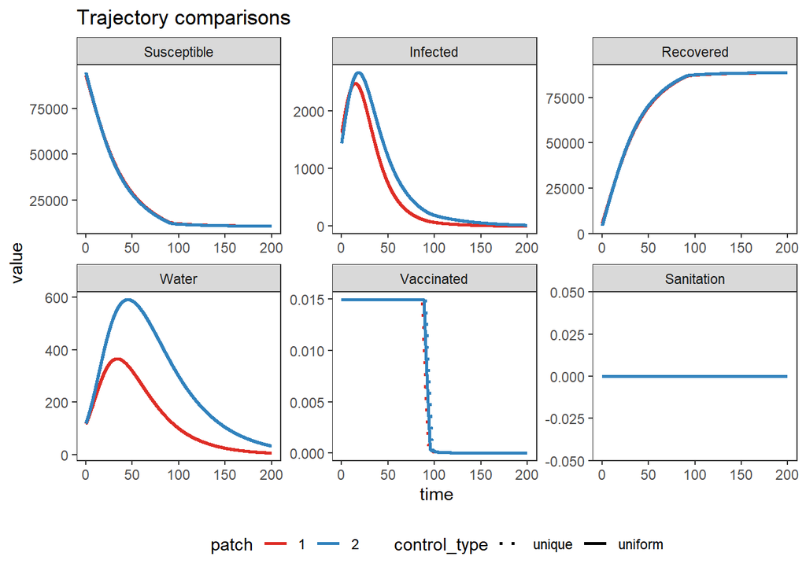

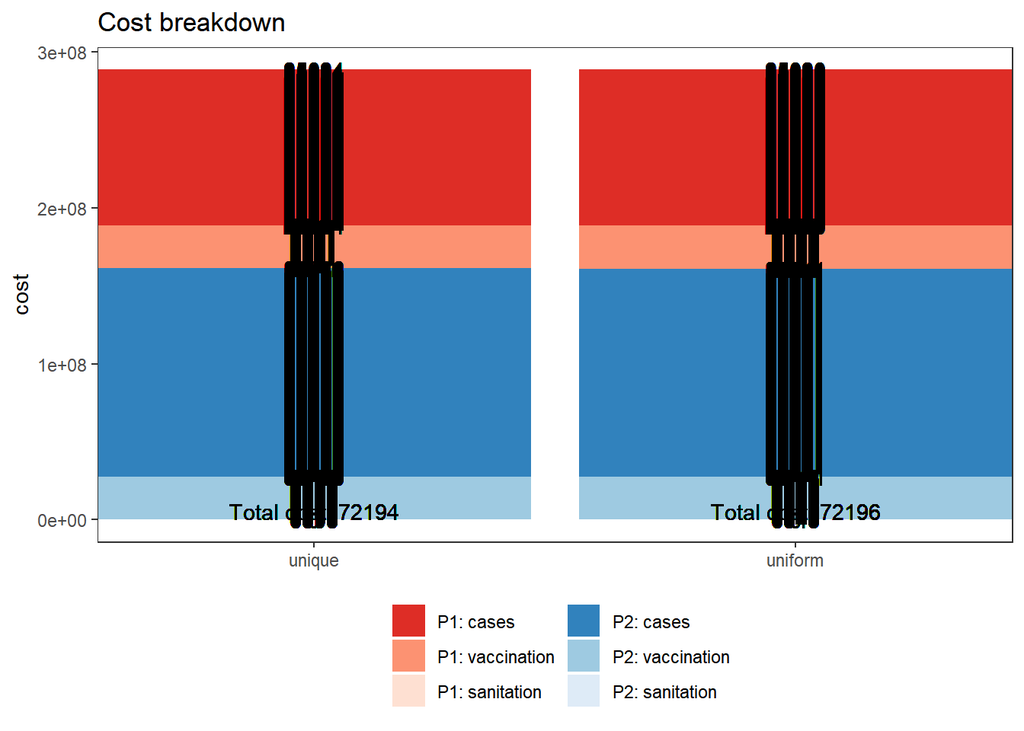

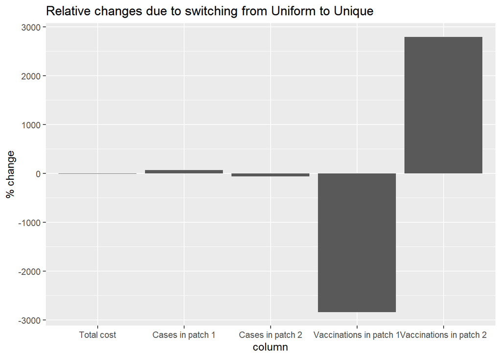

### Sanitation Only

We also consider the case with only sanitation (no vaccination).

Controls start at day 100`.

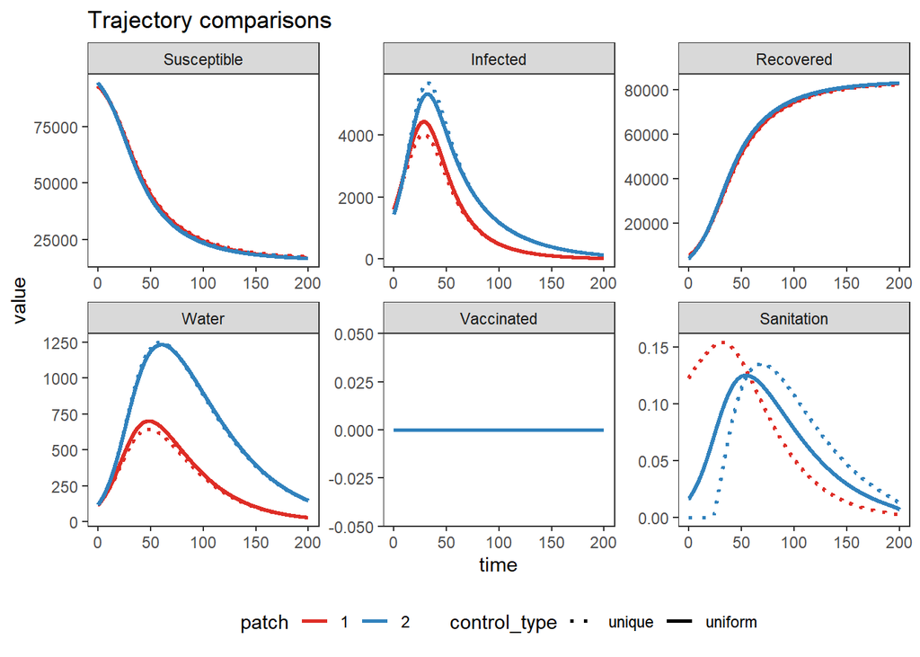

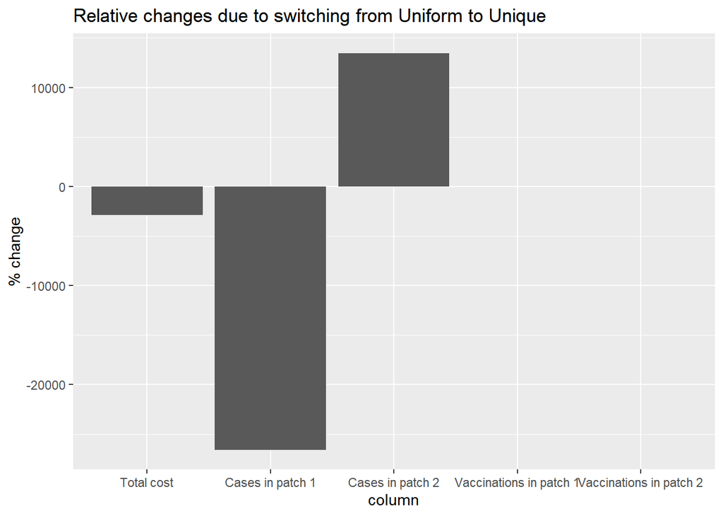

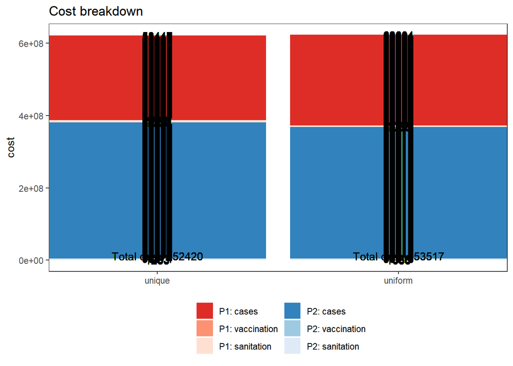

### Both Vaccination and Sanitation

Lastly, we show how results change if we optimize both controls.

Controls start at day 100.

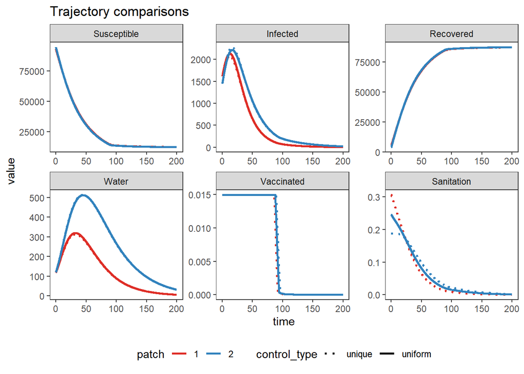

[figure not shown]

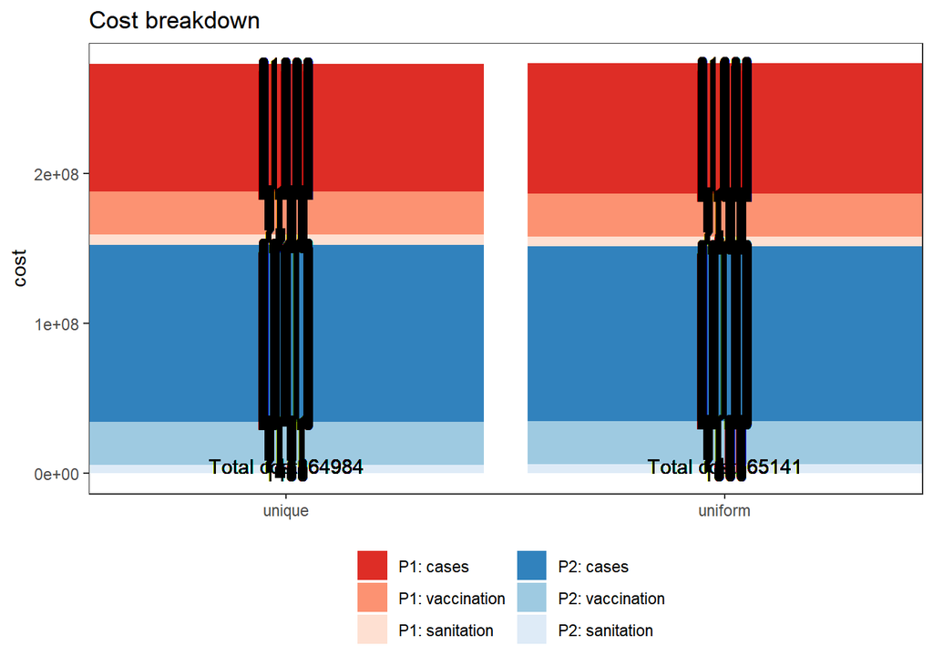

## Experiment 3 (asymmetric movement, m1=0.05, m2=0.1)

### Parameters

The following experiments use these parameters and initial conditions.

Parameters:

| mu1 | mu2 | beta_I1 | beta_I2 | beta_W1 | beta_W2 | v1 | v2 | u1 | u2 | m1 | m2 | n1 | n2 | gamma1 | gamma2 |
| --- | --- | --- | --- | --- | --- | --- | --- | --- | --- | --- | --- | --- | --- | --- | --- |
| 0 | 0 | 2.6e-06 | 2.6e-06 | 1.01e-05 | 1.01e-05 | 0 | 0 | 0 | 0 | 0.05 | 0.1 | 0 | 0 | 0.25 | 0.25 |

| delta1 | delta2 | xi1 | xi2 | nu1 | nu2 | rho1 | rho2 |
| --- | --- | --- | --- | --- | --- | --- | --- |
| 5e-04 | 5e-04 | 0.00756 | 0.00756 | 0.00756 | 0.00756 | 0.025 | 0.025 |

Initial conditions: **need to re-calculate initial conditions with movement**

| S1 | S2 | I1 | I2 | R1 | R2 | W1 | W2 |
| --- | --- | --- | --- | --- | --- | --- | --- |
| 92791 | 94406 | 1609 | 1440 | 5589 | 4145 | 118 | 120 |

Optimal control parameters:

| b1 | b2 | C1 | C2 | epsilon1 | epsilon2 | D1 | D2 | eta1 | eta2 | tol | control_type |
| --- | --- | --- | --- | --- | --- | --- | --- | --- | --- | --- | --- |
| 1 | 1 | 0.125 | 0.125 | 10000 | 10000 | 0.0125 | 0.0125 | 1000 | 1000 | 0.01 | unique |

| v1_min | v1_max | v2_min | v2_max | u1_min | u1_max | u2_min | u2_max |
| --- | --- | --- | --- | --- | --- | --- | --- |
| 0 | 0.015 | 0 | 0.015 | 0 | 0.4 | 0 | 0.4 |

With these parameters, the system has an R0 of about 1.9898893.

### No control

Time 0 corresponds to 100 days since the start of the outbreak. **This is currently incorrect. It’s not taking into account movement**

### Vaccination Only

We consider the case with only vaccination (no sanitation).

Controls start at day 100.

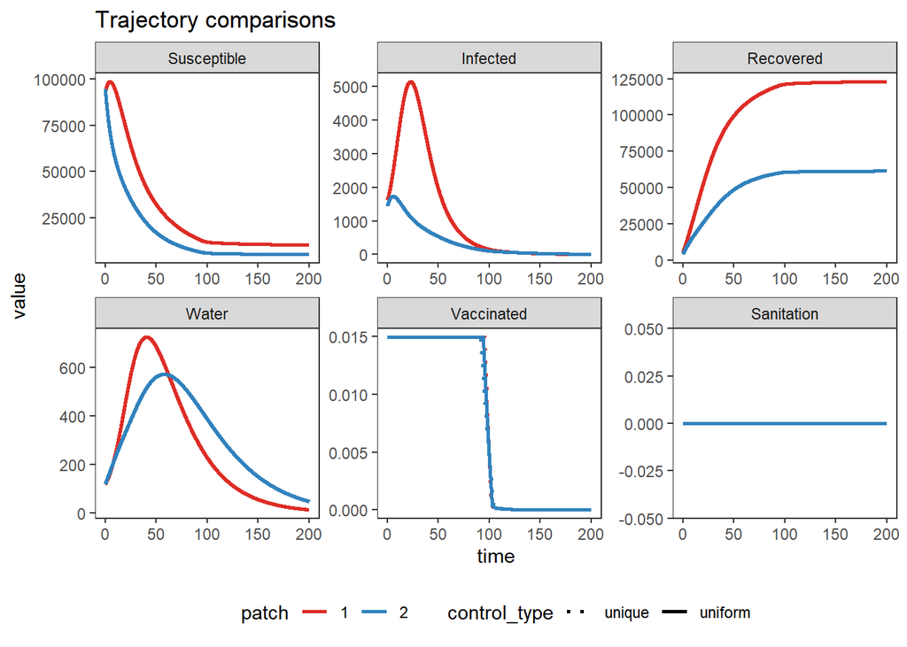

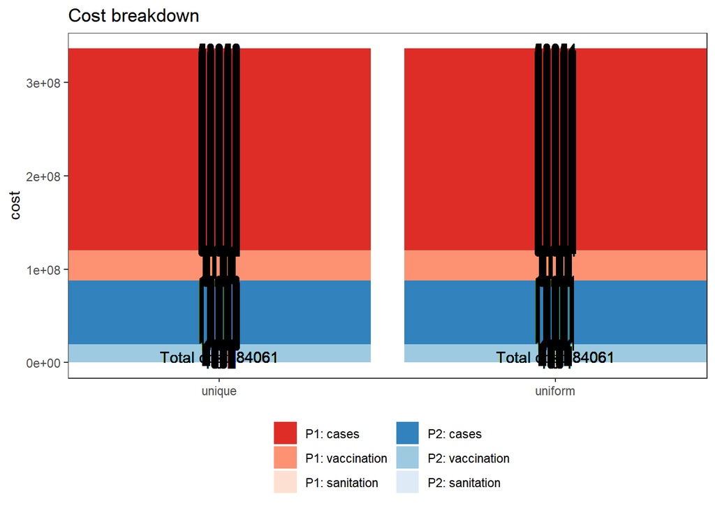

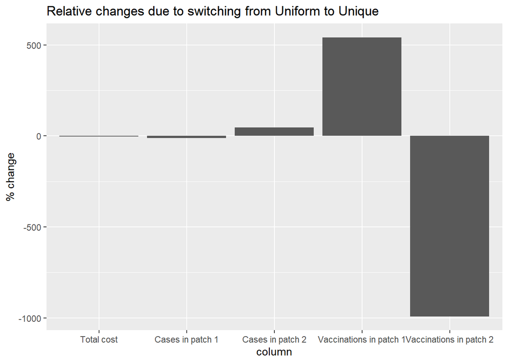

### Sanitation Only

We also consider the case with only sanitation (no vaccination).

Controls start at day 100`.

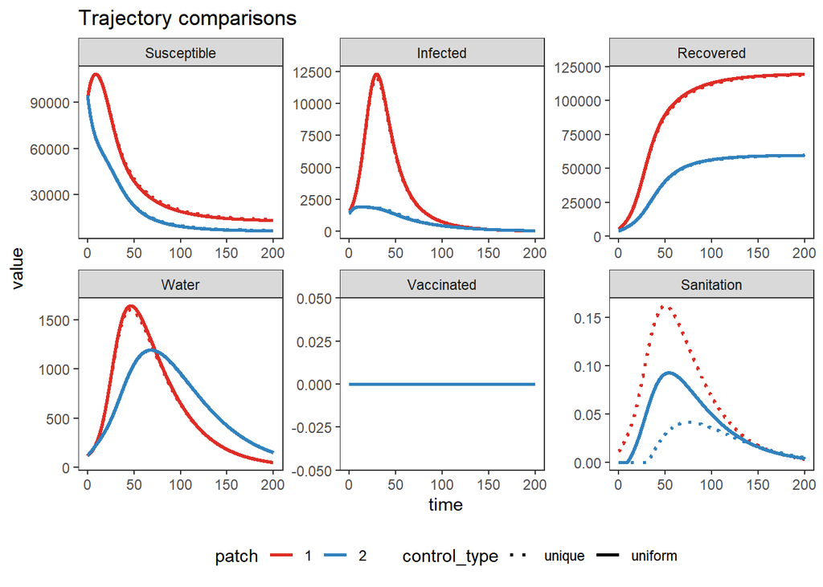

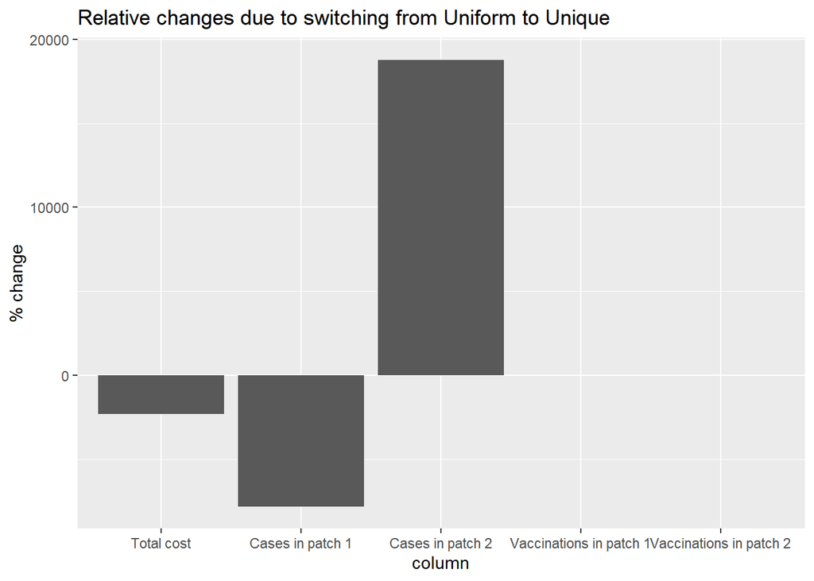

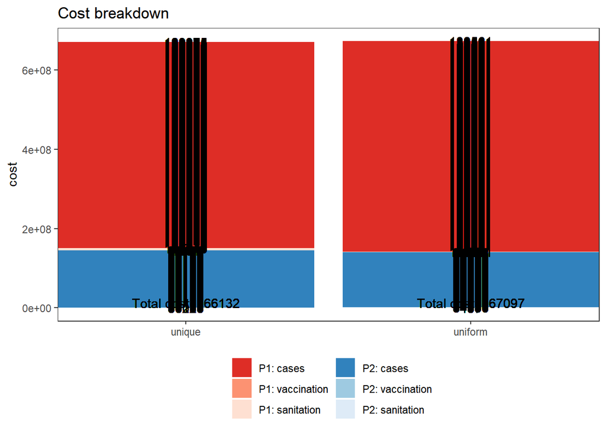

### Both Vaccination and Sanitation

Lastly, we show how results change if we optimize both controls.

Controls start at day 100.

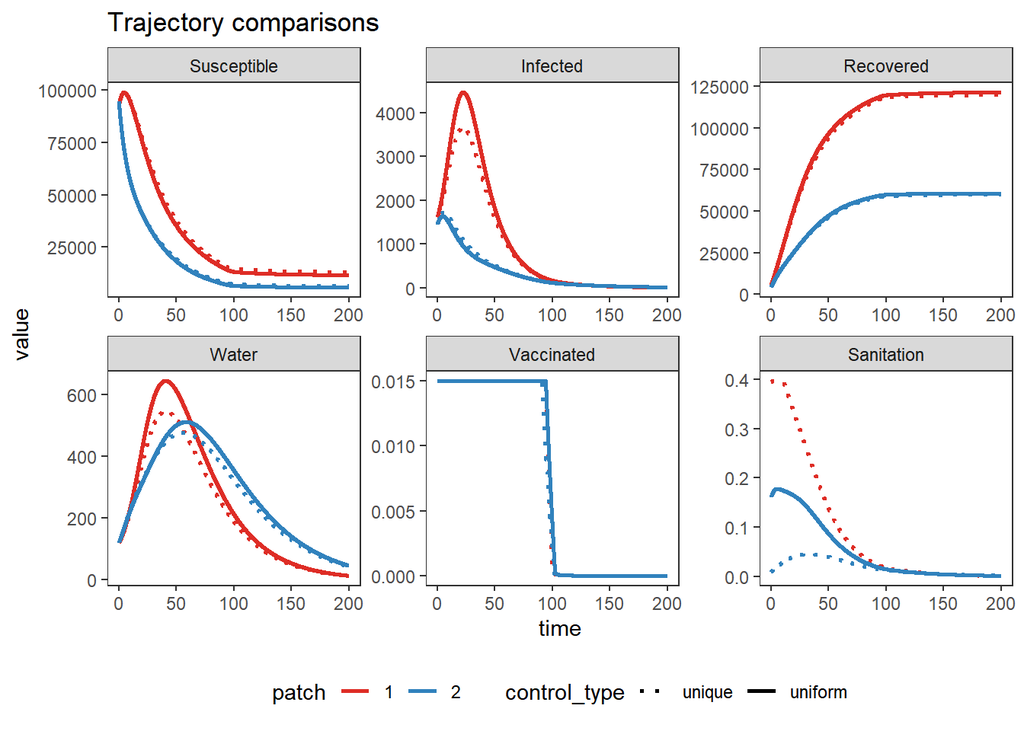

[figure not shown]

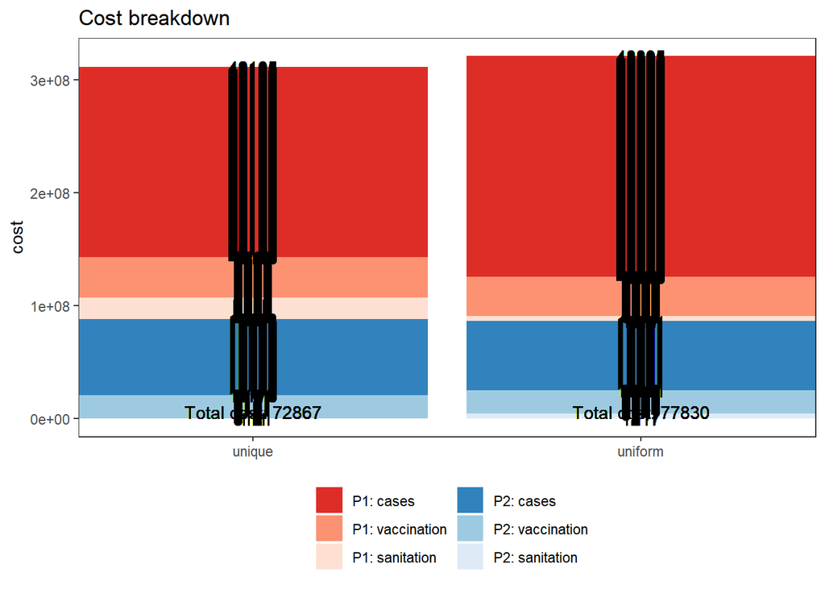

### Parameters

The following experiments use these parameters and initial conditions.

Parameters:

| mu1 | mu2 | beta_I1 | beta_I2 | beta_W1 | beta_W2 | v1 | v2 | u1 | u2 | m1 | m2 | n1 | n2 | gamma1 | gamma2 |
| --- | --- | --- | --- | --- | --- | --- | --- | --- | --- | --- | --- | --- | --- | --- | --- |
| 0 | 0 | 2.6e-06 | 2.6e-06 | 1.01e-05 | 1.01e-05 | 0 | 0 | 0 | 0 | 0.05 | 0.1 | 0 | 0 | 0.25 | 0.25 |

| delta1 | delta2 | xi1 | xi2 | nu1 | nu2 | rho1 | rho2 |
| --- | --- | --- | --- | --- | --- | --- | --- |
| 5e-04 | 5e-04 | 0.00756 | 0.00756 | 0.00756 | 0.00756 | 0.025 | 0.025 |

Initial conditions: **need to re-calculate initial conditions with movement**

| S1 | S2 | I1 | I2 | R1 | R2 | W1 | W2 |
| --- | --- | --- | --- | --- | --- | --- | --- |
| 92791 | 94406 | 1609 | 1440 | 5589 | 4145 | 118 | 120 |

Optimal control parameters:

| b1 | b2 | C1 | C2 | epsilon1 | epsilon2 | D1 | D2 | eta1 | eta2 | tol | control_type |
| --- | --- | --- | --- | --- | --- | --- | --- | --- | --- | --- | --- |
| 1 | 1 | 0.125 | 0.125 | 10000 | 10000 | 0.0125 | 0.0125 | 1000 | 1000 | 0.01 | unique |

| v1_min | v1_max | v2_min | v2_max | u1_min | u1_max | u2_min | u2_max |
| --- | --- | --- | --- | --- | --- | --- | --- |
| 0 | 0.015 | 0 | 0.015 | 0 | 0.4 | 0 | 0.4 |

With these parameters, the system has an R0 of about 1.9898893.

### No control

Time 0 corresponds to 100 days since the start of the outbreak. **This is currently incorrect. It’s not taking into account movement**

### Vaccination Only

We consider the case with only vaccination (no sanitation).

Controls start at day 100.

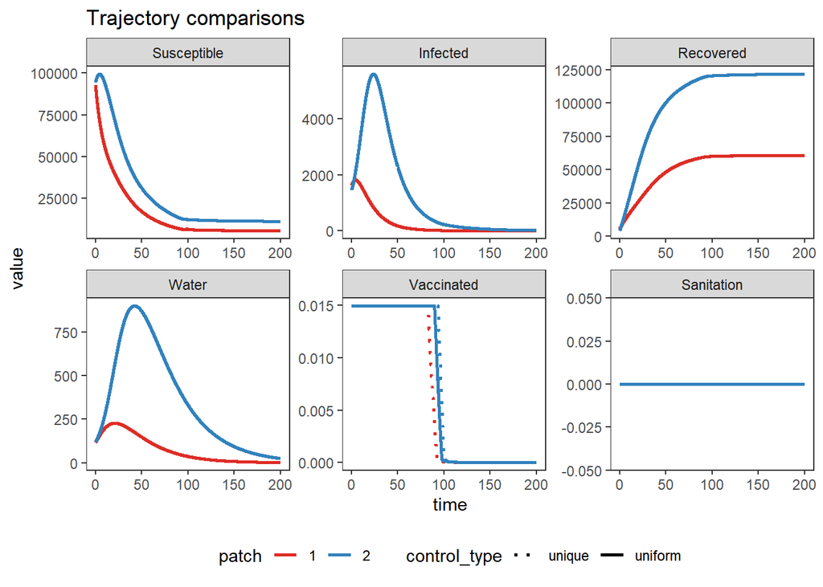

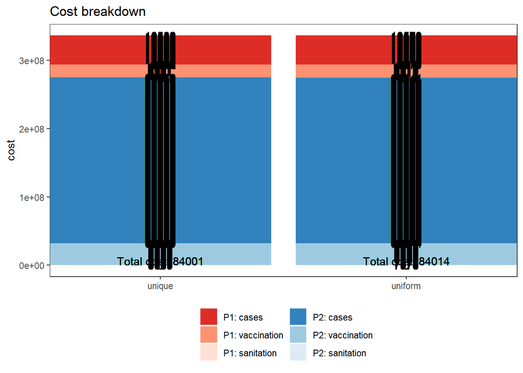

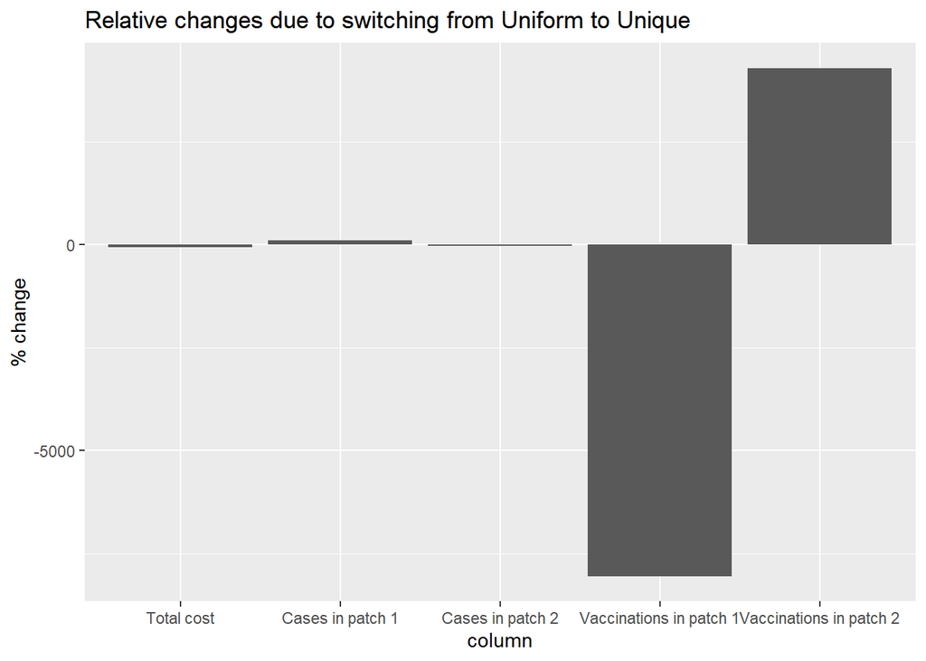

### Sanitation Only

We also consider the case with only sanitation (no vaccination).

Controls start at day 100`.

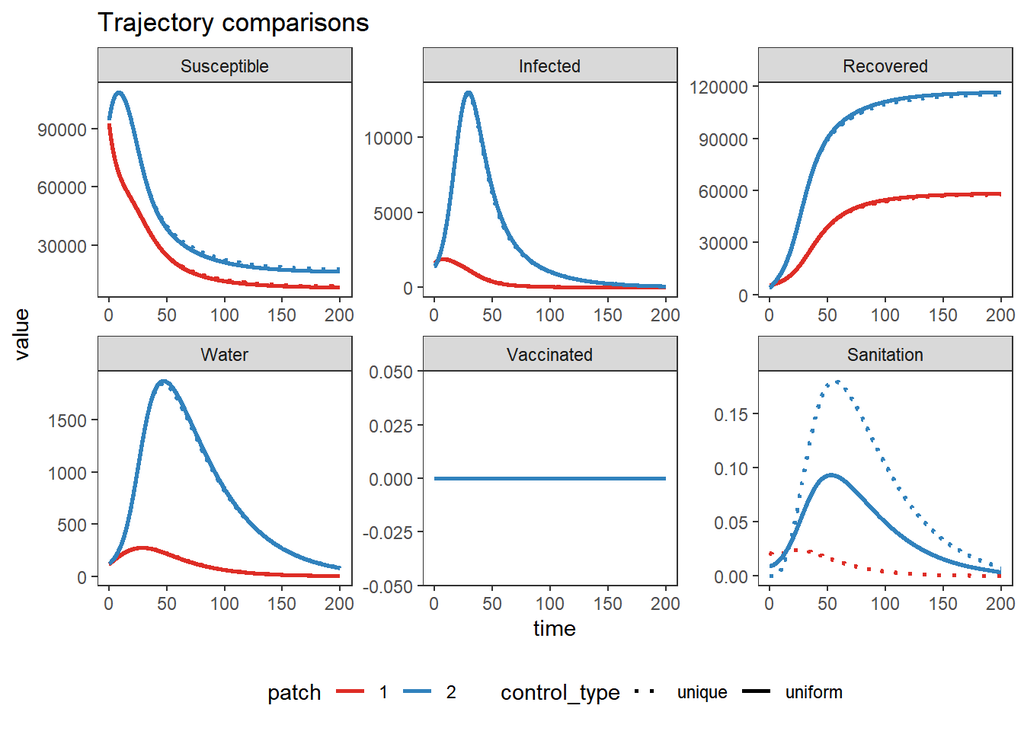

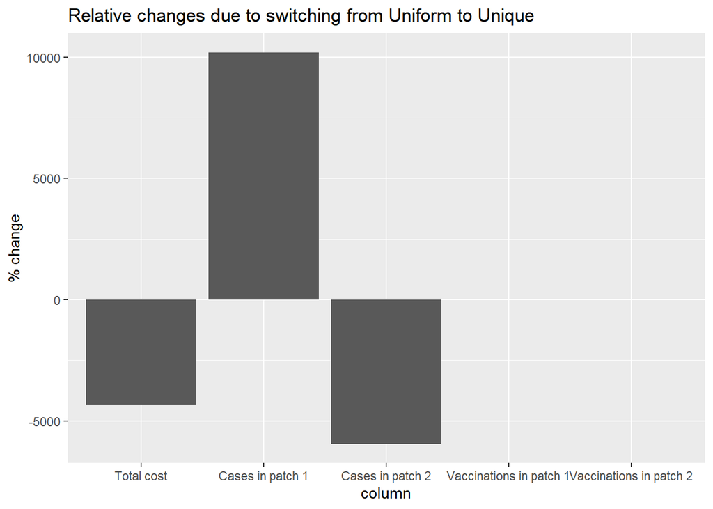

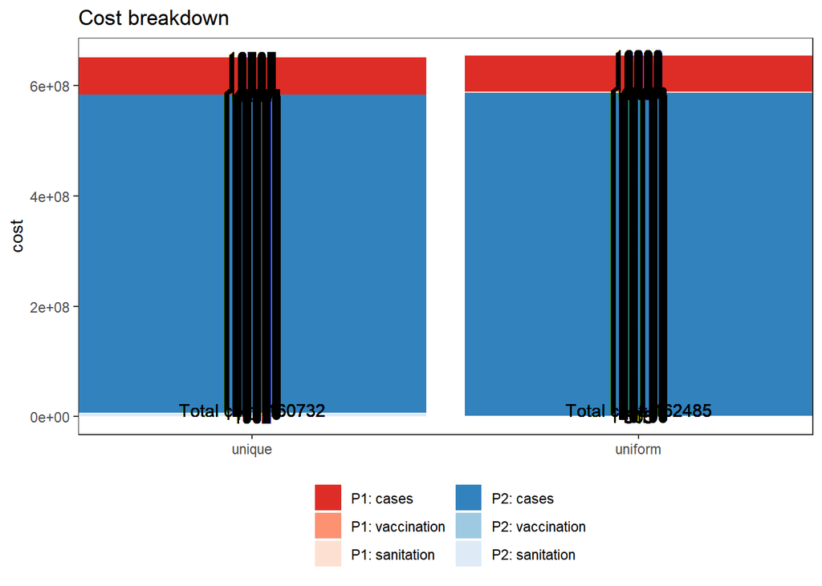

### Both Vaccination and Sanitation

Lastly, we show how results change if we optimize both controls.

Controls start at day 100.

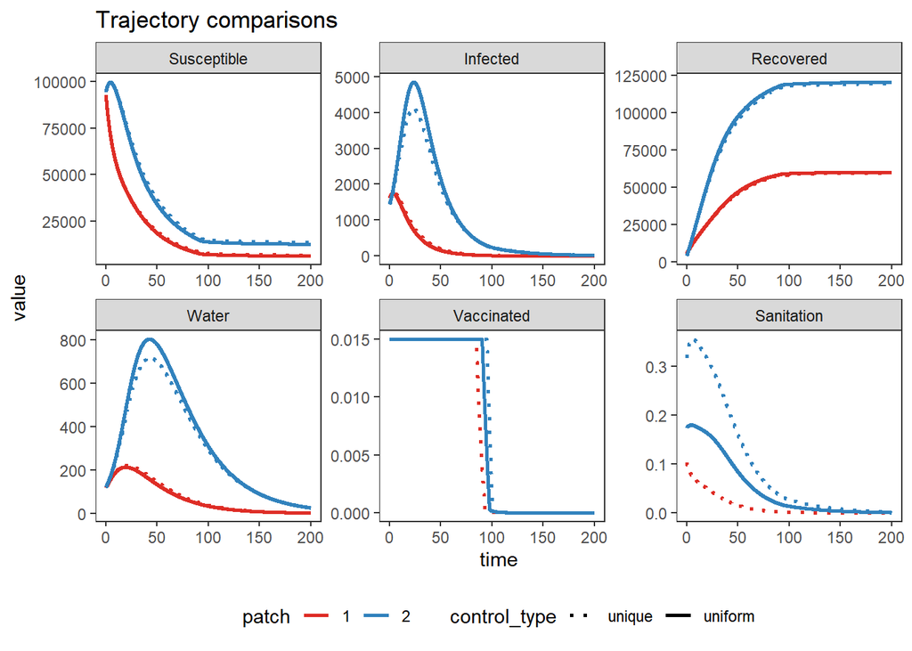

[figure not shown]

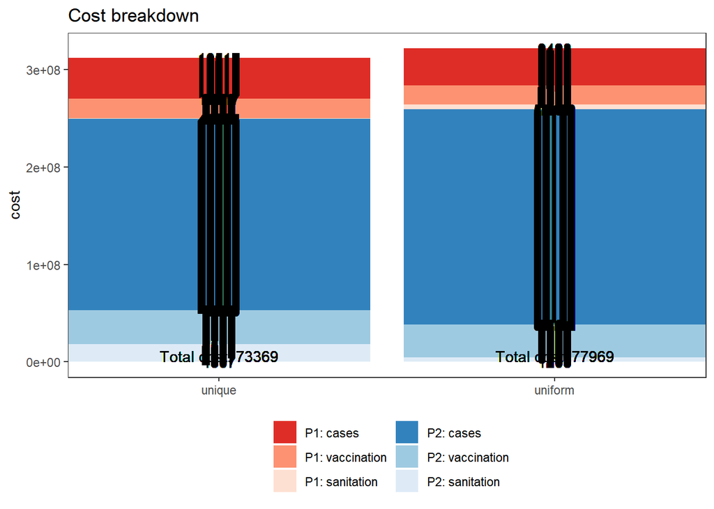

# Ebola

We show similar results instead employing the Ebola model.

## Experiment 0 (no movement between patches)

### Parameters

The following experiments use these parameters and initial conditions.

Parameters:

| mu1 | alpha1 | gammaI1 | gammaH1 | phi1 | deltaI1 | deltaH1 | xi1 | m1 | n1 |
| --- | --- | --- | --- | --- | --- | --- | --- | --- | --- |
| 5.5e-05 | 0.1 | 0.0666667 | 0.028 | 0.236 | 0.024 | 0.01 | 0.222 | 1e-05 | 0 |

| mu2 | alpha2 | gammaI2 | gammaH2 | phi2 | deltaI2 | deltaH2 | xi2 | m2 | n2 |
| --- | --- | --- | --- | --- | --- | --- | --- | --- | --- |
| 5.5e-05 | 0.1 | 0.0666667 | 0.028 | 0.236 | 0.024 | 0.01 | 0.222 | 0.001 | 0 |

Initial conditions:

| S1 | E1 | I1 | H1 | D1 | R1 | S2 | E2 | I2 | H2 | D2 | R2 |
| --- | --- | --- | --- | --- | --- | --- | --- | --- | --- | --- | --- |
| 99300 | 400 | 300 | 0 | 0 | 0 | 1e+05 | 0 | 0 | 0 | 0 | 0 |

Optimal control parameters:

| b1 | b2 | C1 | C2 | epsilon1 | epsilon2 | control_type | tol | v1 | v2 |
| --- | --- | --- | --- | --- | --- | --- | --- | --- | --- |
| 1 | 1 | 0.01 | 0.01 | 50000 | 50000 | uniform | 0.01 | 0 | 0 |

| v1_min | v1_max | v2_min | v2_max | betaI1 | betaI2 | betaD1 | betaD2 | N1 | N2 |
| --- | --- | --- | --- | --- | --- | --- | --- | --- | --- |
| 0 | 0.015 | 0 | 0.015 | 1e-07 | 1e-07 | 5.94e-05 | 5.94e-05 | 1e+05 | 1e+05 |

*Need to add Ebola R0 calculation*

### No control

Time 0 corresponds to 100 days since the start of the outbreak. **This is currently incorrect. It’s not taking into account movement**

### Vaccination Only

We consider the case with only vaccination (no TBD).

Controls start at day 100.

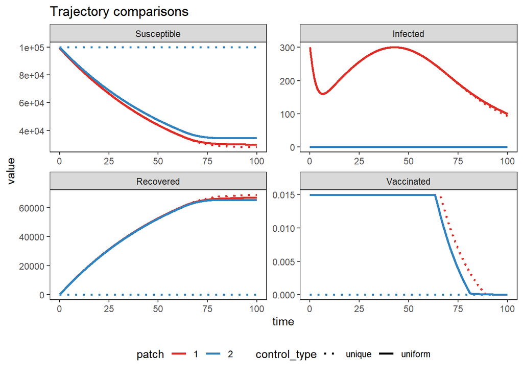

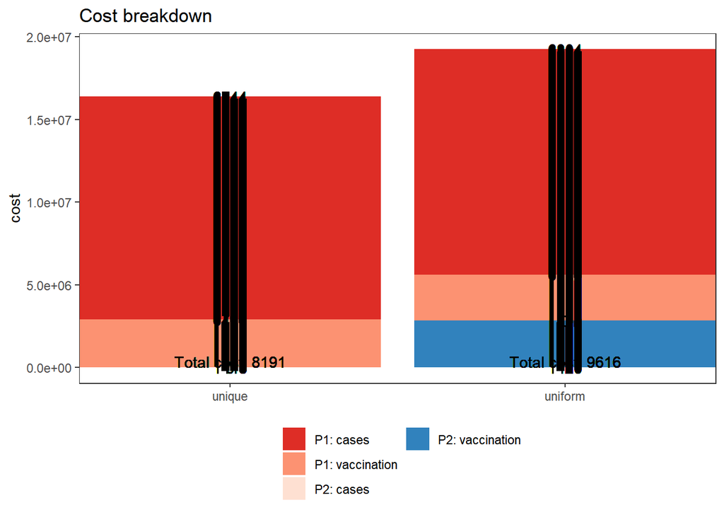

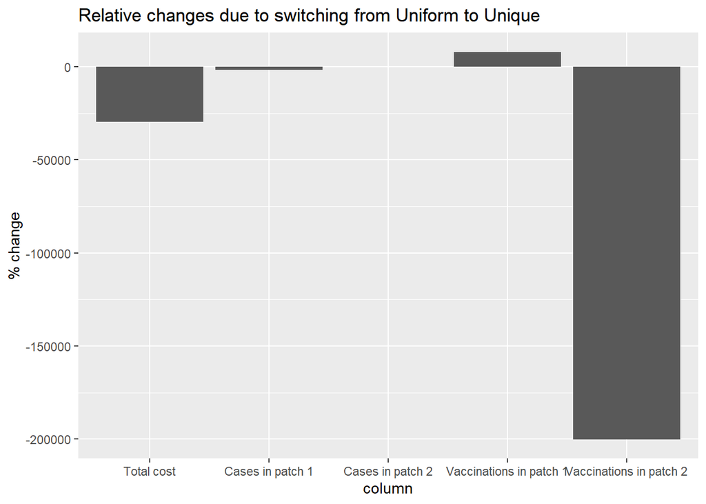

### TBD Only

We also consider the case with only TBD (no vaccination).

Controls start at day 100`.

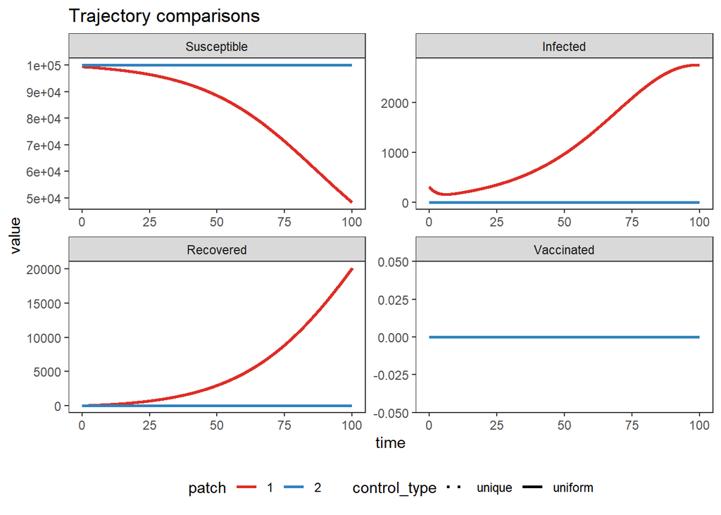

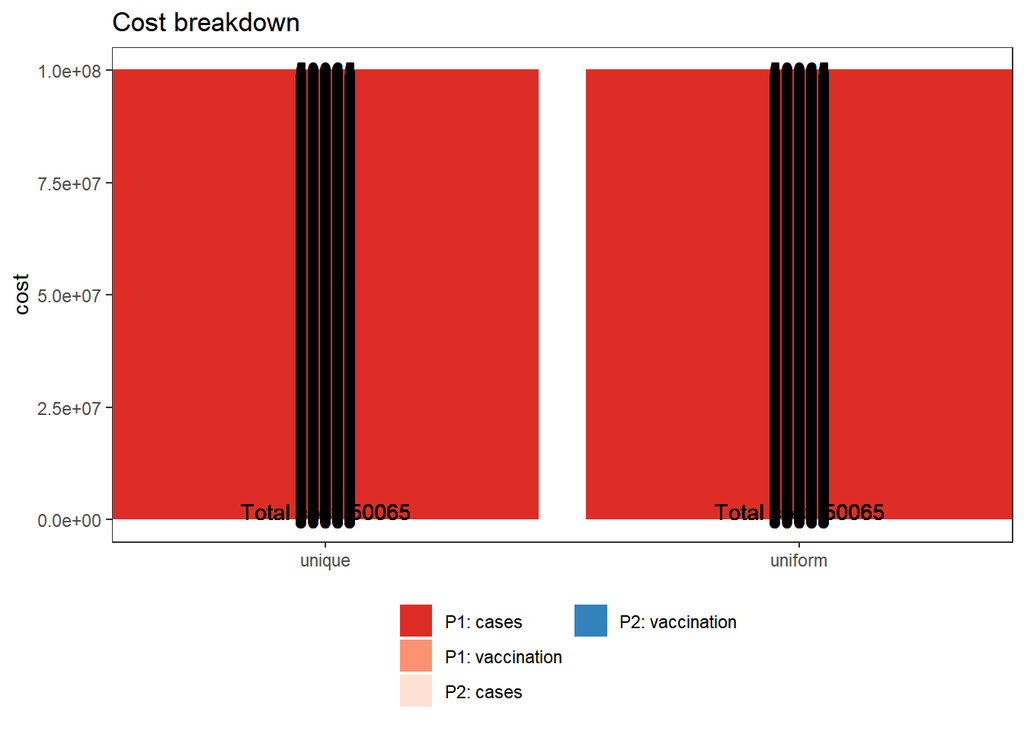

### Both Vaccination and TBD

Lastly, we show how results change if we optimize both controls.

Controls start at day 100.

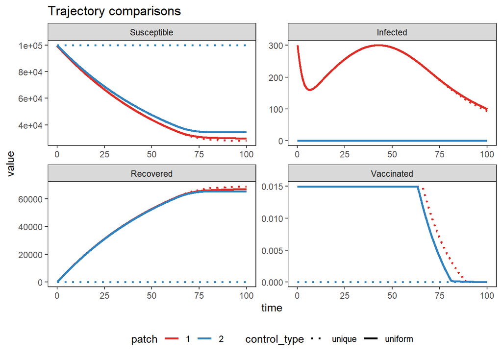

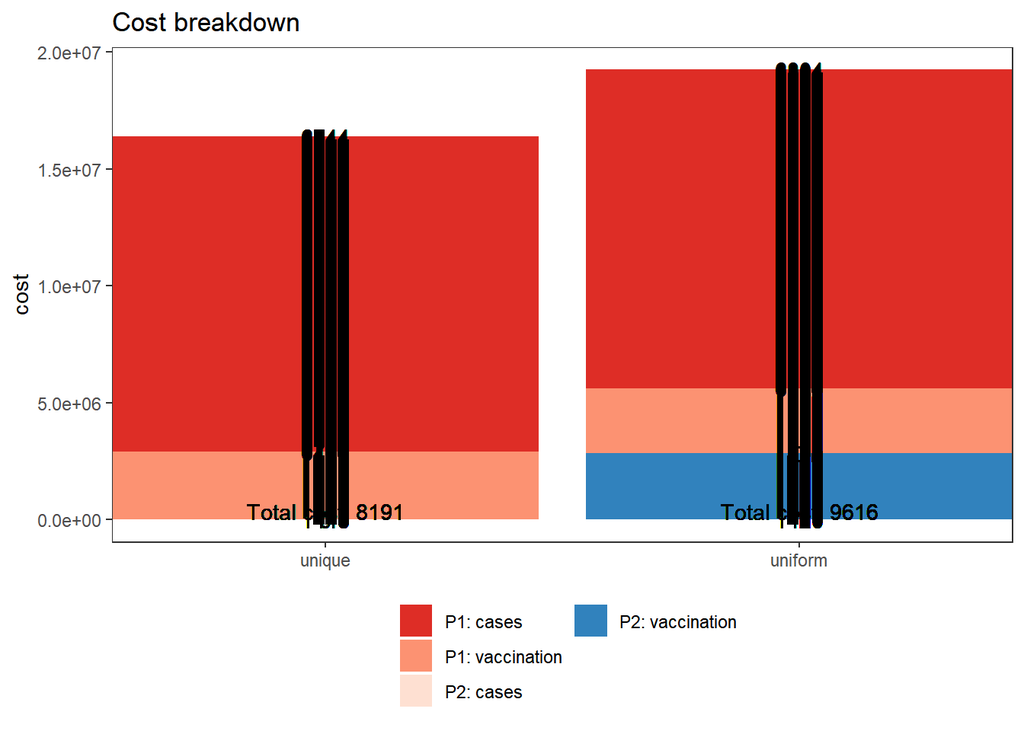

### Parameters

The following experiments use these parameters and initial conditions.

Parameters:

| mu1 | alpha1 | gammaI1 | gammaH1 | phi1 | deltaI1 | deltaH1 | xi1 | m1 | n1 |
| --- | --- | --- | --- | --- | --- | --- | --- | --- | --- |
| 5.5e-05 | 0.1 | 0.0666667 | 0.028 | 0.236 | 0.024 | 0.01 | 0.222 | 1e-05 | 0 |

| mu2 | alpha2 | gammaI2 | gammaH2 | phi2 | deltaI2 | deltaH2 | xi2 | m2 | n2 |
| --- | --- | --- | --- | --- | --- | --- | --- | --- | --- |
| 5.5e-05 | 0.1 | 0.0666667 | 0.028 | 0.236 | 0.024 | 0.01 | 0.222 | 0.001 | 0 |

Initial conditions:

| S1 | E1 | I1 | H1 | D1 | R1 | S2 | E2 | I2 | H2 | D2 | R2 |
| --- | --- | --- | --- | --- | --- | --- | --- | --- | --- | --- | --- |
| 99300 | 400 | 300 | 0 | 0 | 0 | 1e+05 | 0 | 0 | 0 | 0 | 0 |

Optimal control parameters:

| b1 | b2 | C1 | C2 | epsilon1 | epsilon2 | control_type | tol | v1 | v2 |
| --- | --- | --- | --- | --- | --- | --- | --- | --- | --- |
| 1 | 1 | 0.01 | 0.01 | 50000 | 50000 | uniform | 0.01 | 0 | 0 |

| v1_min | v1_max | v2_min | v2_max | betaI1 | betaI2 | betaD1 | betaD2 | N1 | N2 |
| --- | --- | --- | --- | --- | --- | --- | --- | --- | --- |
| 0 | 0.015 | 0 | 0.015 | 1e-07 | 1e-07 | 5.94e-05 | 5.94e-05 | 1e+05 | 1e+05 |

*Need to add Ebola R0 calculation*

### No control

Time 0 corresponds to 100 days since the start of the outbreak. **This is currently incorrect. It’s not taking into account movement**

### Vaccination Only

We consider the case with only vaccination (no TBD).

Controls start at day 100.

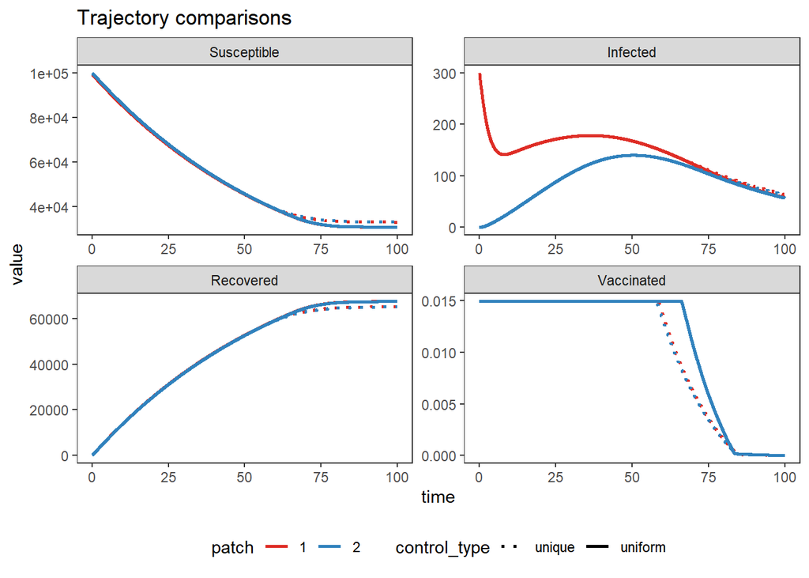

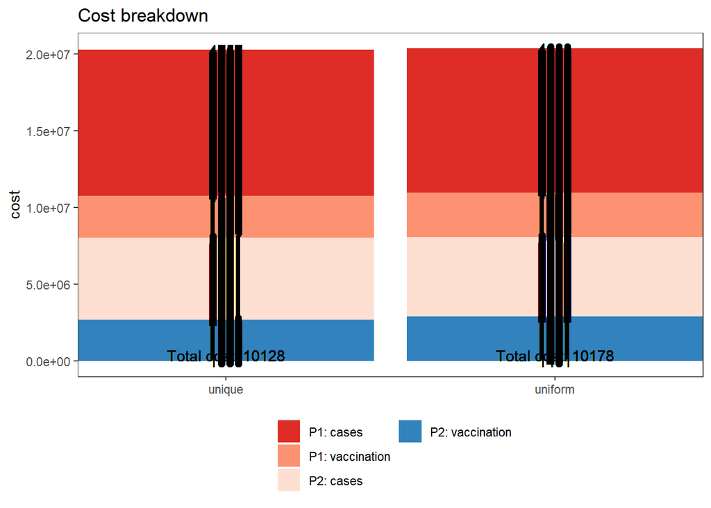

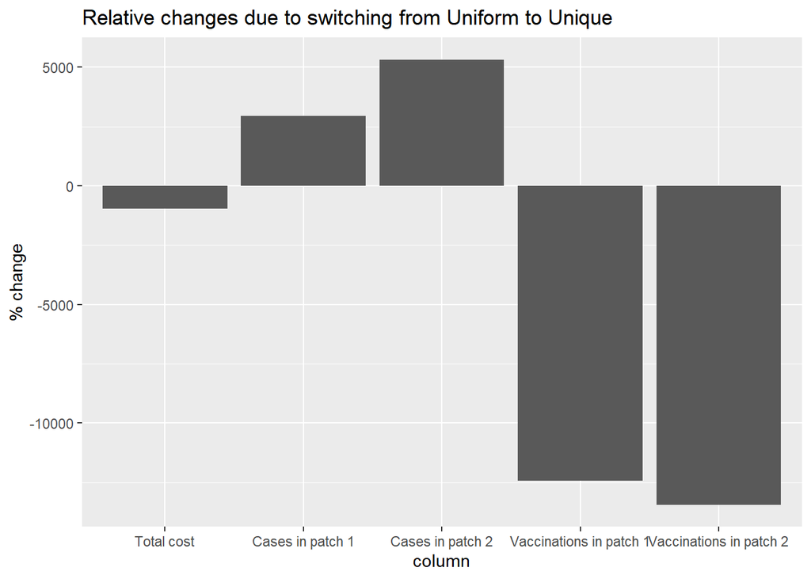

### TBD Only

We also consider the case with only TBD (no vaccination).

Controls start at day 100`.

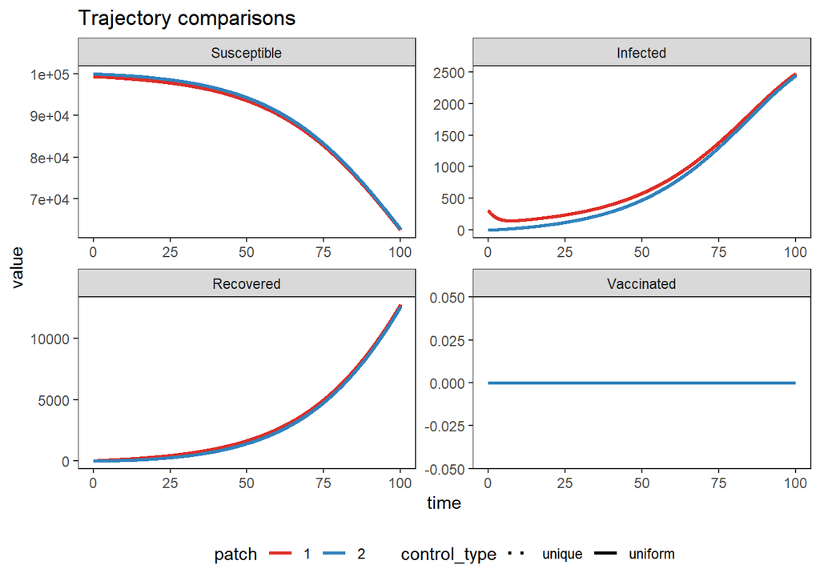

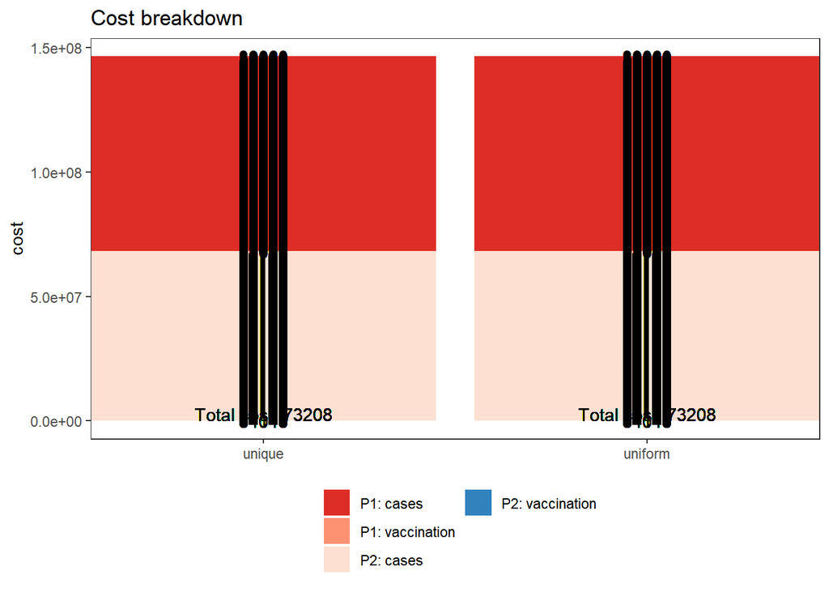

### Both Vaccination and TBD

Lastly, we show how results change if we optimize both controls.

Controls start at day 100.

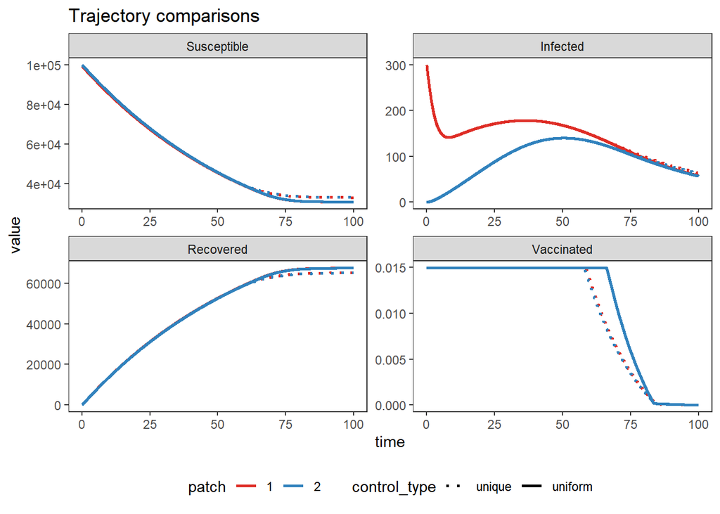

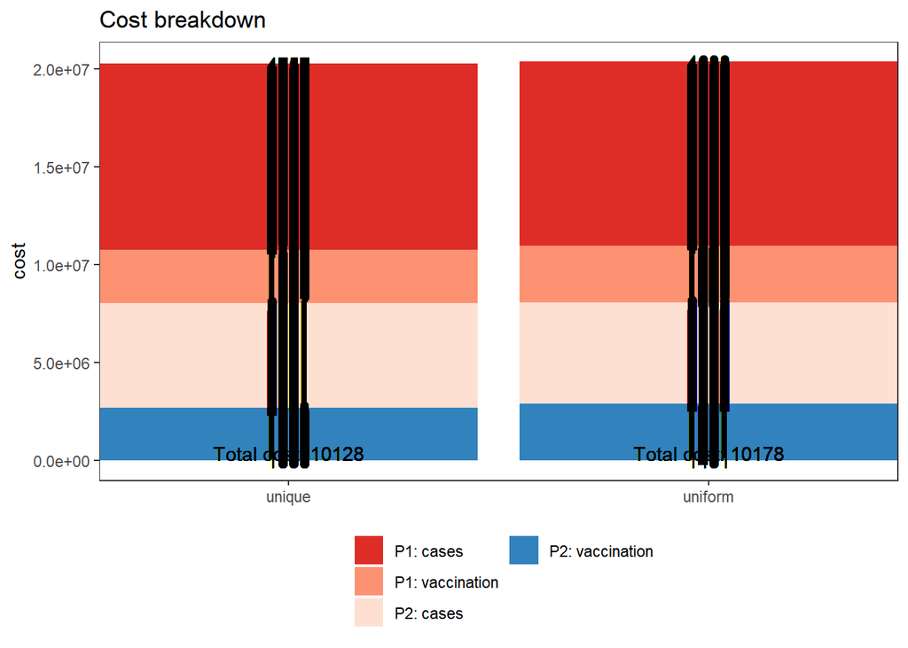

### Parameters

The following experiments use these parameters and initial conditions.

Parameters:

| mu1 | alpha1 | gammaI1 | gammaH1 | phi1 | deltaI1 | deltaH1 | xi1 | m1 | n1 |
| --- | --- | --- | --- | --- | --- | --- | --- | --- | --- |
| 5.5e-05 | 0.1 | 0.0666667 | 0.028 | 0.236 | 0.024 | 0.01 | 0.222 | 1e-05 | 0 |

| mu2 | alpha2 | gammaI2 | gammaH2 | phi2 | deltaI2 | deltaH2 | xi2 | m2 | n2 |
| --- | --- | --- | --- | --- | --- | --- | --- | --- | --- |
| 5.5e-05 | 0.1 | 0.0666667 | 0.028 | 0.236 | 0.024 | 0.01 | 0.222 | 0.001 | 0 |

Initial conditions:

| S1 | E1 | I1 | H1 | D1 | R1 | S2 | E2 | I2 | H2 | D2 | R2 |
| --- | --- | --- | --- | --- | --- | --- | --- | --- | --- | --- | --- |
| 99300 | 400 | 300 | 0 | 0 | 0 | 1e+05 | 0 | 0 | 0 | 0 | 0 |

Optimal control parameters:

| b1 | b2 | C1 | C2 | epsilon1 | epsilon2 | control_type | tol | v1 | v2 |
| --- | --- | --- | --- | --- | --- | --- | --- | --- | --- |
| 1 | 1 | 0.01 | 0.01 | 50000 | 50000 | uniform | 0.01 | 0 | 0 |

| v1_min | v1_max | v2_min | v2_max | betaI1 | betaI2 | betaD1 | betaD2 | N1 | N2 |
| --- | --- | --- | --- | --- | --- | --- | --- | --- | --- |
| 0 | 0.015 | 0 | 0.015 | 1e-07 | 1e-07 | 5.94e-05 | 5.94e-05 | 1e+05 | 1e+05 |

*Need to add Ebola R0 calculation*

### No control

Time 0 corresponds to 100 days since the start of the outbreak. **This is currently incorrect. It’s not taking into account movement**

### Vaccination Only

We consider the case with only vaccination (no TBD).

Controls start at day 100.

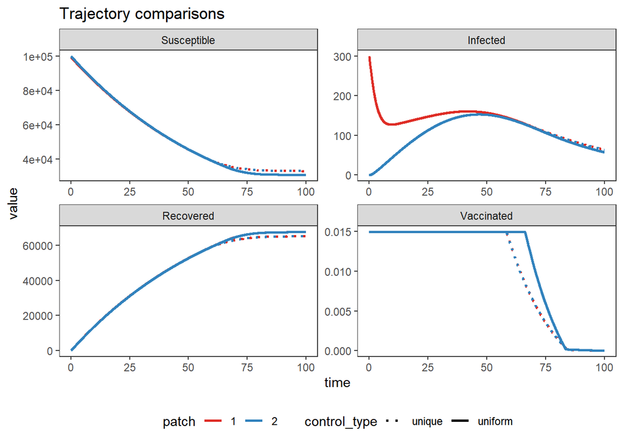

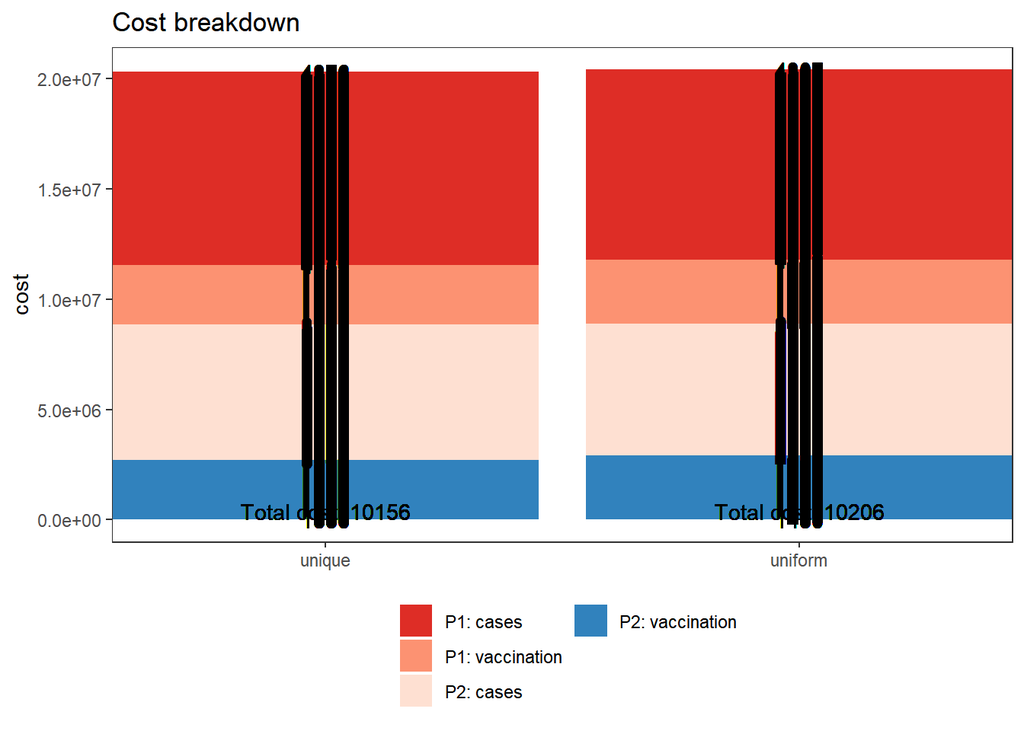

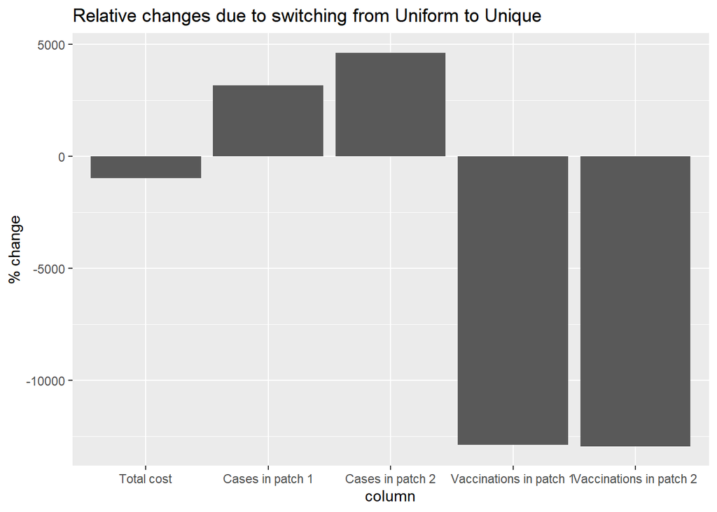

### TBD Only

We also consider the case with only TBD (no vaccination).

Controls start at day 100`.

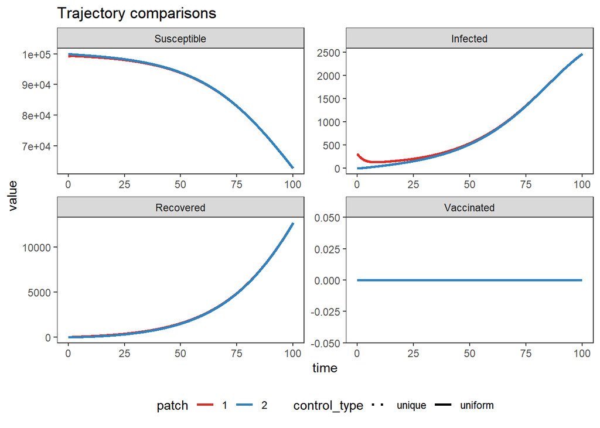

[figure not shown]

### Both Vaccination and TBD

Lastly, we show how results change if we optimize both controls.

Controls start at day 100.

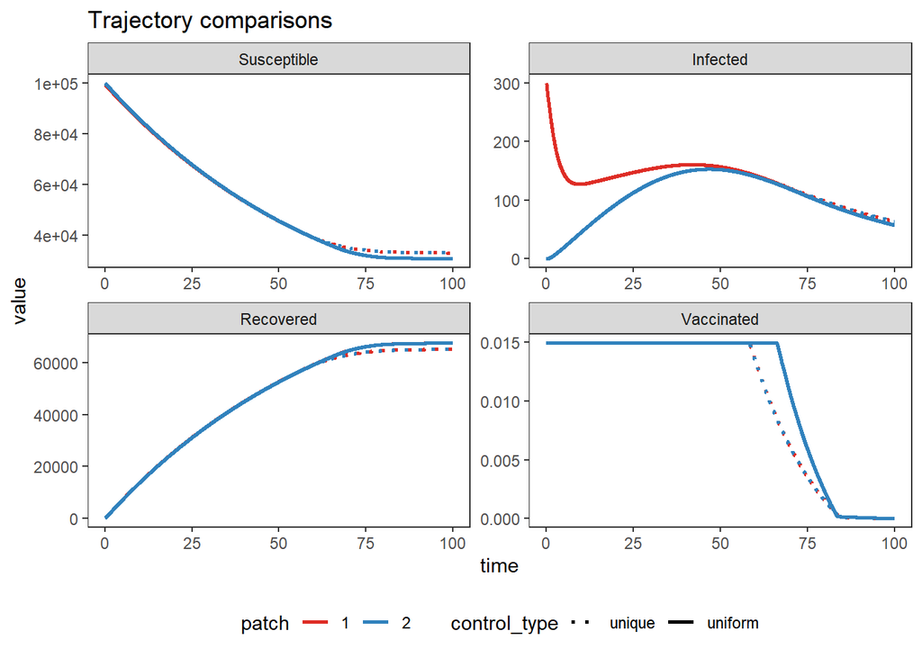

[figure not shown]

### Parameters

The following experiments use these parameters and initial conditions.

Parameters:

| mu1 | alpha1 | gammaI1 | gammaH1 | phi1 | deltaI1 | deltaH1 | xi1 | m1 | n1 |
| --- | --- | --- | --- | --- | --- | --- | --- | --- | --- |
| 5.5e-05 | 0.1 | 0.0666667 | 0.028 | 0.236 | 0.024 | 0.01 | 0.222 | 1e-05 | 0 |

| mu2 | alpha2 | gammaI2 | gammaH2 | phi2 | deltaI2 | deltaH2 | xi2 | m2 | n2 |
| --- | --- | --- | --- | --- | --- | --- | --- | --- | --- |
| 5.5e-05 | 0.1 | 0.0666667 | 0.028 | 0.236 | 0.024 | 0.01 | 0.222 | 0.001 | 0 |

Initial conditions:

| S1 | E1 | I1 | H1 | D1 | R1 | S2 | E2 | I2 | H2 | D2 | R2 |
| --- | --- | --- | --- | --- | --- | --- | --- | --- | --- | --- | --- |
| 99300 | 400 | 300 | 0 | 0 | 0 | 1e+05 | 0 | 0 | 0 | 0 | 0 |

Optimal control parameters:

| b1 | b2 | C1 | C2 | epsilon1 | epsilon2 | control_type | tol | v1 | v2 |
| --- | --- | --- | --- | --- | --- | --- | --- | --- | --- |
| 1 | 1 | 0.01 | 0.01 | 50000 | 50000 | uniform | 0.01 | 0 | 0 |

| v1_min | v1_max | v2_min | v2_max | betaI1 | betaI2 | betaD1 | betaD2 | N1 | N2 |
| --- | --- | --- | --- | --- | --- | --- | --- | --- | --- |
| 0 | 0.015 | 0 | 0.015 | 1e-07 | 1e-07 | 5.94e-05 | 5.94e-05 | 1e+05 | 1e+05 |

### Vaccination Only

We consider the case with only vaccination (no TBD).

Controls start at day 100.

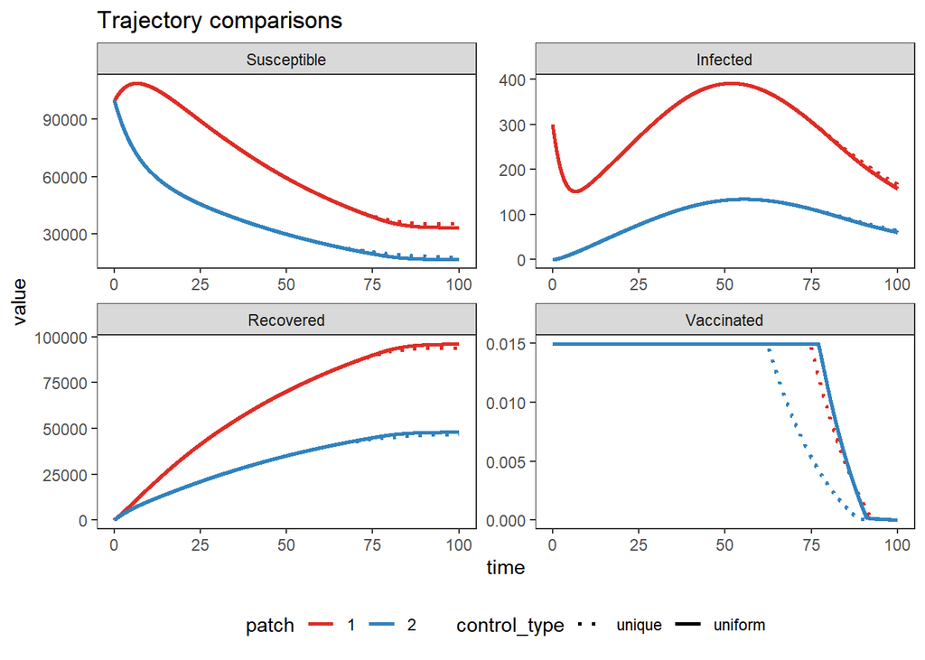

[figure not shown]

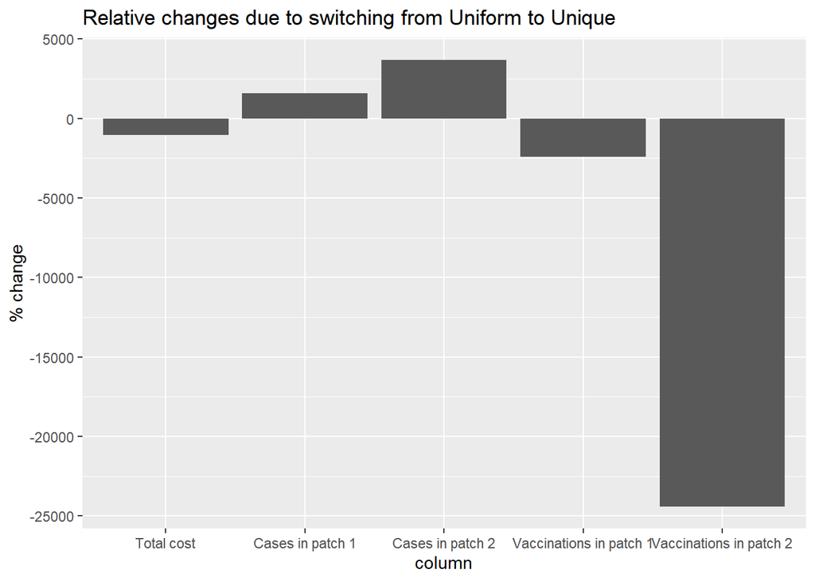

### TBD Only

We also consider the case with only TBD (no vaccination).

Controls start at day 100`.

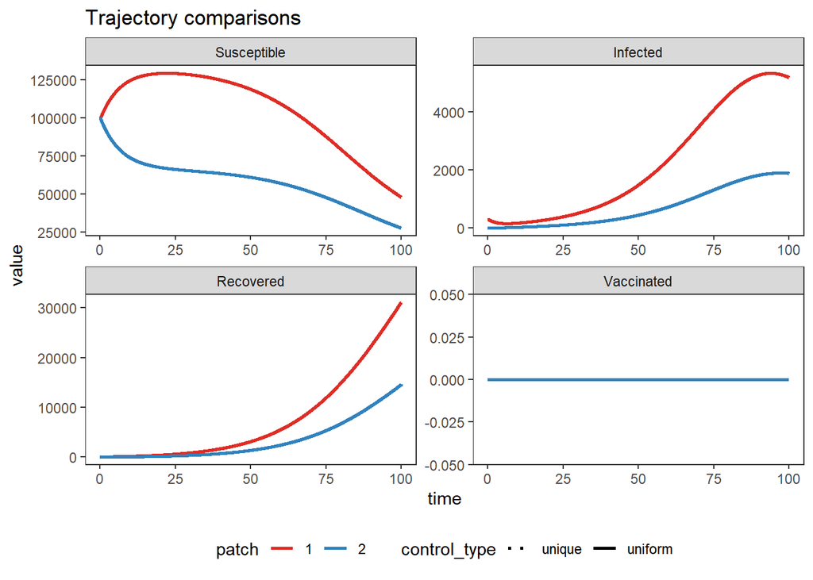

[figure not shown]

### Both Vaccination and TBD

Lastly, we show how results change if we optimize both controls.

Controls start at day 100.

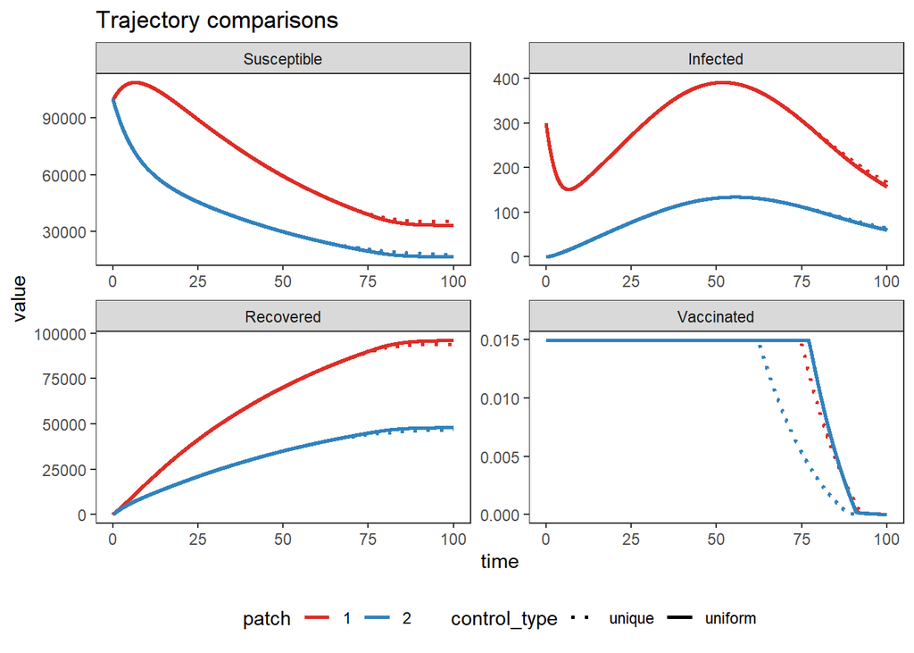

[figure not shown]

### Parameters

The following experiments use these parameters and initial conditions.

Parameters:

| mu1 | alpha1 | gammaI1 | gammaH1 | phi1 | deltaI1 | deltaH1 | xi1 | m1 | n1 |
| --- | --- | --- | --- | --- | --- | --- | --- | --- | --- |
| 5.5e-05 | 0.1 | 0.0666667 | 0.028 | 0.236 | 0.024 | 0.01 | 0.222 | 1e-05 | 0 |

| mu2 | alpha2 | gammaI2 | gammaH2 | phi2 | deltaI2 | deltaH2 | xi2 | m2 | n2 |
| --- | --- | --- | --- | --- | --- | --- | --- | --- | --- |
| 5.5e-05 | 0.1 | 0.0666667 | 0.028 | 0.236 | 0.024 | 0.01 | 0.222 | 0.001 | 0 |

Initial conditions:

| S1 | E1 | I1 | H1 | D1 | R1 | S2 | E2 | I2 | H2 | D2 | R2 |
| --- | --- | --- | --- | --- | --- | --- | --- | --- | --- | --- | --- |
| 99300 | 400 | 300 | 0 | 0 | 0 | 1e+05 | 0 | 0 | 0 | 0 | 0 |

Optimal control parameters:

| b1 | b2 | C1 | C2 | epsilon1 | epsilon2 | control_type | tol | v1 | v2 |
| --- | --- | --- | --- | --- | --- | --- | --- | --- | --- |
| 1 | 1 | 0.01 | 0.01 | 50000 | 50000 | uniform | 0.01 | 0 | 0 |

| v1_min | v1_max | v2_min | v2_max | betaI1 | betaI2 | betaD1 | betaD2 | N1 | N2 |
| --- | --- | --- | --- | --- | --- | --- | --- | --- | --- |
| 0 | 0.015 | 0 | 0.015 | 1e-07 | 1e-07 | 5.94e-05 | 5.94e-05 | 1e+05 | 1e+05 |